# Introduction to *B. pertussis* fitness model

Noémie Lefrancq - ncmjl2@cam.ac.uk

28/04/2022

# Introduction

This document has been created to provide an introduction to run the fitness model described in **Global spatial dynamics and vaccine-induced fitness changes of *Bordetella pertussis*** , Lefrancq N. & Bouchez V. *et al.*, [*Science Translational Medicine*](https://www.science.org/doi/10.1126/scitranslmed.abn3253) (2022).

To quantify the fitness of *B. pertussis* strains, our model makes use of the isolates from 20 countries with more than 10 sequences in our dataset (fewer sequences than this threshold did not allow for sufficient data points to provide a robust estimate of genotype distributions over time).

We compute $f_{i,ref}$, the relative abundance of each strain $i$ with respect to a chosen $ref$ strain. We chose the *ptxP3/fim3-1/PRN-positive* genotype as the reference strain. In a sensitivity analysis, we found that the choice of the reference strain did not affect the results, providing that the chosen genotype was present in all countries, for most of the years. We then use a simple logistic model to capture the evolution of this abundance, at each time $t$:
$$\frac{d f_{i,ref}}{dt} = r_{i,ref} ⋅ f_{i, ref} ⋅ (1 - f_{i, ref}), \space \space \space \space\space with \space i∈{strains} \setminus ref,\space and \space f_{i, ref} (t=0) = f_{i, ref, 0}$$
where $r_i$, ref is the growth rate of that abundance, shared across all countries and $f_{i, ref, 0}$ is the initial relative abundance of the strain $i$ with respect to a chosen $ref$.

By identifying the growth rate $r_i$ of each strain $i$, one can derive the relative fitness if strain $i$ in the population.

For further information of the model and code, please contact: Noémie Lefrancq at ncmjl2@cam.ac.uk .

# 1 - Data creation and formatting

The run the model, one need the following data, written in the *data* section of the *stan* code *Model_relative_fitness_genotypes_vaccine_switch_250421.stan*:

```
data {
  // Shape data
    int nb_genotypes; // number of clades
    int nb_years; // length of the data
    int nb_countries; // number of countries

  // Data
    int data_genotype_non_ref[nb_genotypes-1, nb_years, nb_countries]; // counts
    int data_genotype_ref[nb_years, nb_countries]; // counts
    int data_total_number[nb_years, nb_countries]; // reference for each year // real because of the divison in lp for the freq
    int non_zero_country_year[nb_years, nb_countries];
    int non_zero_country_year_genotype[nb_genotypes-1, nb_years, nb_countries];
    int number_zeros_country_year;
    int number_zeros_country_year_genotype;

  // ACV implementation
    int yearIntroduction[nb_countries]; // dates of introdution for each country

  // F0 estimation
    int yearF0[nb_countries];

  // Fitness vector
    int number_R_pre_vacc;
    int number_R_post_vacc;
}
```

The output of this section is the rds file *Data_model_allcountries_refgeno3.rds*, provided in the GitHub.

## 1.1 - Pre-processing of raw data

### 1.1.A Load packages and data

```r
## Load necessary packages
library(questionr)
library(treeio)
library(ape)
library(rstan)
library(gridExtra)
library(grid)
library(gtable)
library(ggpubr)
library(binom)
library(stringr)

## Load metadata ###############################################
data = readRDS('Estimate_relative_fitness/data_tips_and_nodes_clades.rds')
data_antigens = read.csv('Data/Metadata_analyses_26012022.csv', sep = ';')

## Load tree
tree.beast = read.beast('Data/Beast_tree_MCC_26012022.tree')
tree = tree.beast@phylo

## Get distance between nodes
mat.dist.nodes = dist.nodes(tree)
diag(mat.dist.nodes) = NA
nb_tips = length(tree$tip.label)

## Check the continent labels of each node
## For continents, do not consider nodes that are more than 5 years away from any sequence
threshold = 5 ## threshold of minimum distance to at least one tip
node_vect = (nb_tips+1):(nb_tips*2-1)
list_to_remove = NULL
list_nb = NULL
for (i in node_vect){
  a = which(mat.dist.nodes[i,1:nb_tips] < threshold)
  list_nb = c(list_nb, length(a))
  if (length(a) == 0){list_to_remove = c(list_to_remove, i)}
}

## Take out these values
data = data[-list_to_remove,]

## Common values
data$date = 2019-round(as.numeric(data$height))
max_date = 2030
min_date = min(data$date)
min_date = 1940
seasons = seq(min_date, max_date, 1)

## List of clades
clades_prn_pos = levels(as.factor(data$clade))[c(1,2,3)]
clades_prn_neg = as.numeric(levels(as.factor(data$clade))[-c(1,2,3)])[order(as.numeric(levels(as.factor(data$clade))[-c(1,2,3)]))]

## Divide PRN clades into country specific clades
###### Remove country state when posterior probability is <0.9
data$country = data$Countries
a = which(as.numeric(data$Countries.prob) < 0.9)
data$country[a] = NA
data = data[which(!is.na(data$country)),]

data$clade = as.factor(data$clade)
t = table(data$clade)
a = which(t < 5)
a = as.data.frame(a)
m = match(data$clade, row.names(a))
data = data[which(is.na(m)),]

clades = levels(as.factor(as.character(data$clade)))

### Data ACV introduction - to cut ACV PERIOD
vaccine_introduction =  c(1999, 1999, 1997, 2012, 2007, 1997, 2005, 2005, 2004, 1996, 2002, 2019, 1995, 2005, 1998, 1998, 2019, 2000, 1997, 1981)
vaccine_introduction_country = c('AU', 'BE', 'CA', 'CN', 'CZ', 'DK', 'ES', 'FI', 'FR', 'IE', 'IL', 'IR', 'IT', 'NL', 'NO', 'SE', 'TN', 'UK', 'US', 'JP')
cut_at_ACV = F

### Data ACV introduction - to cut WCV PERIOD
vaccine_introduction =  c(1999, 1999, 1997, 2012, 2007, 1997, 2005, 2005, 2004, 1996, 2002, 2019, 1995, 2005, 1998, 1998, 2019, 2000, 1997, 1981)
vaccine_introduction_country = c('AU', 'BE', 'CA', 'CN', 'CZ', 'DK', 'ES', 'FI', 'FR', 'IE', 'IL', 'IR', 'IT', 'NL', 'NO', 'SE', 'TN', 'UK', 'US', 'JP')
cut_at_WCV = F
```

### 1.1.B Compute the frequency of each clade, by window of time

First define the function that will be processing each country:

```r
compute_clade_numbers_country_1 = function(country){
  data_tmp = data
  if(cut_at_ACV == T){
    data_tmp = data[which(data$date <= vaccine_introduction[which(vaccine_introduction_country == country)]),]
  }
  if(cut_at_WCV == T){
    data_tmp = data[which(data$date >= vaccine_introduction[which(vaccine_introduction_country == country)]),]
  }

  list_x_prn_neg = as.list(rep(NA, length(clades_prn_neg)))
  for (i in 1:length(list_x_prn_neg)) list_x_prn_neg[[i]] = rep(NA, length(seasons))
  list_x_prn_pos = as.list(rep(NA, length(clades_prn_pos)))
  for (i in 1:length(list_x_prn_pos)) list_x_prn_pos[[i]] = rep(NA, length(seasons))
  number_total = rep(NA, length(seasons)-2)

  for (i in 1:(length(seasons))){
    sum = 0
    # print(i)
    for (j in 1:length(list_x_prn_neg)) {
      list_x_prn_neg[[j]][i] =  round(length(which((data_tmp$date >= seasons[i] &
                                                      data_tmp$date <= seasons[i]) &
                                                     (data_tmp$country == country | is.na(data_tmp$country) == T) &
                                                     data_tmp$clade == clades_prn_neg[j])), digits = 0)
      sum = sum + list_x_prn_neg[[j]][i]
    }
    for (k in 1:length(list_x_prn_pos)) {
      list_x_prn_pos[[k]][i] =   round(length(which((data_tmp$date >= seasons[i] &
                                                       data_tmp$date <= seasons[i]) &
                                                      (data_tmp$country == country | is.na(data_tmp$country) == T) &
                                                      data_tmp$clade == clades_prn_pos[k])), digits = 0)
      sum = sum + list_x_prn_pos[[k]][i]
    }
    number_total[i] = round(sum, digits = 0)
  }
  list_clades_neg = clades_prn_neg
  return(list(list_x_prn_neg, list_x_prn_pos, list_clades_neg, number_total))
}
```

For each country, run the above function:

```r
## Make sure the dates are rounded
data$date = floor(as.numeric(data$date))

## For each country, run the above function
list_AU = compute_clade_numbers_country_1('AU')
list_BE = compute_clade_numbers_country_1('BE')
list_CA = compute_clade_numbers_country_1('CA')
list_CN = compute_clade_numbers_country_1('CN')
list_CZ = compute_clade_numbers_country_1('CZ')
list_DK = compute_clade_numbers_country_1('DK')
list_ES = compute_clade_numbers_country_1('ES')
list_FI = compute_clade_numbers_country_1('FI')
list_FR = compute_clade_numbers_country_1('FR')
list_IE = compute_clade_numbers_country_1('IE')
list_IL = compute_clade_numbers_country_1('IL')
list_IR = compute_clade_numbers_country_1('IR')
list_IT = compute_clade_numbers_country_1('IT')
list_JP = compute_clade_numbers_country_1('JP')
list_NL = compute_clade_numbers_country_1('NL')
list_NO = compute_clade_numbers_country_1('NO')
list_SE = compute_clade_numbers_country_1('SE')
list_TN = compute_clade_numbers_country_1('TN')
list_UK = compute_clade_numbers_country_1('UK')
list_US = compute_clade_numbers_country_1('US')

## Store the years (seasons) used
################################################
seasons_plot = seasons
nb_years = length(seasons)
```

### 1.1.C Add genotype information to each clade

First define the function that will be processing each country:

```r
compute_data_obs_country = function(list_x_prn_neg, list_x_prn_pos, list_clades_neg){
  data_obs = NULL
  ## Set prn - data
  for (i in 1:length(list_clades_neg)){
    a =  which(data$clade == as.character(list_clades_neg[i]))
    seqs = data$label[a]
    seqs = seqs[which(is.na(seqs) == F)]
    b = match(seqs, data_antigens$?..Isolate)
    c = data_antigens[b,]
    fim = freq(as.factor(as.character(c$fim3)))
    fim = row.names(fim)[which(fim$`val%`>50)]
    if(length(fim) == 0) fim = NA
    ptxP = freq(as.factor(as.character(c$ptxP)))
    ptxp = row.names(ptxP)[which(ptxP$`val%`>50)]
    if(length(ptxp) == 0) ptxp = NA
    data_obs[[i]] = data.frame('Clade' = rep(list_clades_neg[i], length(seasons_plot)),
                               'count' = list_x_prn_neg[[i]],
                               'Year' = seasons_plot,
                               'Prn_exp' = rep(0, length(seasons_plot)),
                               'ptxp_allele' = rep(ptxp, length(seasons_plot)),
                               'Fim_3_allele' = rep(fim, length(seasons_plot)))
  }

  ## Set prn+ data
  for (i in 1: length(clades_prn_pos)){
    if (clades_prn_pos[i] == '0a'){
      fim = 'fim3-1'
      ptxp = 'ptxP1'
    }
    if (clades_prn_pos[i] == '0b'){
      fim = 'fim3-1'
      ptxp = 'ptxP3'
    }
    if (clades_prn_pos[i] == '0c'){
      fim = 'fim3-2'
      ptxp = 'ptxP3'
    }
    data_obs[[length(list_clades_neg) + i]] = data.frame('Clade' = rep(clades_prn_pos[i], length(seasons_plot)),
                                                         'count' = list_x_prn_pos[[i]],
                                                         'Year' = seasons_plot,
                                                         'Prn_exp' = rep(1, length(seasons_plot)),
                                                         'ptxp_allele' = rep(ptxp, length(seasons_plot)),
                                                         'Fim_3_allele' = rep(fim, length(seasons_plot)))
  }
  return(data_obs)
}
```

For each country, run the above function:

```r
data_obs_AU = compute_data_obs_country(list_AU[[1]], list_AU[[2]], list_AU[[3]])
data_obs_BE = compute_data_obs_country(list_BE[[1]], list_BE[[2]], list_BE[[3]])
data_obs_CA = compute_data_obs_country(list_CA[[1]], list_CA[[2]], list_CA[[3]])
data_obs_CN = compute_data_obs_country(list_CN[[1]], list_CN[[2]], list_CN[[3]])
data_obs_CZ = compute_data_obs_country(list_CZ[[1]], list_CZ[[2]], list_CZ[[3]])
data_obs_DK = compute_data_obs_country(list_DK[[1]], list_DK[[2]], list_DK[[3]])
data_obs_ES = compute_data_obs_country(list_ES[[1]], list_ES[[2]], list_ES[[3]])
data_obs_FI = compute_data_obs_country(list_FI[[1]], list_FI[[2]], list_FI[[3]])
data_obs_FR = compute_data_obs_country(list_FR[[1]], list_FR[[2]], list_FR[[3]])
data_obs_IE = compute_data_obs_country(list_IE[[1]], list_IE[[2]], list_IE[[3]])
data_obs_IL = compute_data_obs_country(list_IL[[1]], list_IL[[2]], list_IL[[3]])
data_obs_IR = compute_data_obs_country(list_IR[[1]], list_IR[[2]], list_IR[[3]])
data_obs_IT = compute_data_obs_country(list_IT[[1]], list_IT[[2]], list_IT[[3]])
data_obs_JP = compute_data_obs_country(list_JP[[1]], list_JP[[2]], list_JP[[3]])
data_obs_NL = compute_data_obs_country(list_NL[[1]], list_NL[[2]], list_NL[[3]])
data_obs_NO = compute_data_obs_country(list_NO[[1]], list_NO[[2]], list_NO[[3]])
data_obs_SE = compute_data_obs_country(list_SE[[1]], list_SE[[2]], list_SE[[3]])
data_obs_TN = compute_data_obs_country(list_TN[[1]], list_TN[[2]], list_TN[[3]])
data_obs_UK = compute_data_obs_country(list_UK[[1]], list_UK[[2]], list_UK[[3]])
data_obs_US = compute_data_obs_country(list_US[[1]], list_US[[2]], list_US[[3]])
```

### 1.1.D Merge clades by genotype, by country

First define the function that will be processing each country:

```r
genotypes_clades = matrix(NA, length(data_obs_FR), 3)
for(i in 1:nrow(genotypes_clades)){
  genotypes_clades[i,1] = as.character(data_obs_FR[[i]][1,c(4)])
  genotypes_clades[i,2] = as.character(data_obs_FR[[i]][1,c(5)])
  genotypes_clades[i,3] = as.character(data_obs_FR[[i]][1,c(6)])
}

merge_clades_per_genotype = function(d){
  data_merged = NULL

  ## ancestral: ptxP1 - fim3-1 - prn+
  tmp = matrix(0, nb_years, 6)
  colnames(tmp) = c('Clade', 'count', 'Year',  'Prn_exp', 'ptxp_allele', 'Fim_3_allele')
  tmp[,1] = rep(1, nb_years)
  tmp[,3] = d[[1]][,3]
  a = which(genotypes_clades[,1] == "1" &
              genotypes_clades[,2] == "ptxP1" &
              genotypes_clades[,3] == "fim3-1")
  for(i in 1:nb_years){
    tmp[i,4:6] = c('prn+', 'ptxP1', 'fim3-1')
  }
  for(i in a){
    tmp[,2] = as.numeric(tmp[,2])+as.numeric(d[[i]][,2])
  }
  data_merged[[1]] = tmp

  ## ptxP1 - fim3-1 - prn-
  tmp = matrix(0, nb_years, 6)
  colnames(tmp) = c('Clade', 'count', 'Year',  'Prn_exp', 'ptxp_allele', 'Fim_3_allele')
  tmp[,1] = rep(2, nb_years)
  tmp[,3] = d[[1]][,3]
  a = which(genotypes_clades[,1] == "0" &
              genotypes_clades[,2] == "ptxP1" &
              genotypes_clades[,3] == "fim3-1")
  for(i in 1:nb_years){
    tmp[i,4:6] = c('prn-', 'ptxP1', 'fim3-1')
  }
  for(i in a){
    tmp[,2] = as.numeric(tmp[,2])+as.numeric(d[[i]][,2])
  }
  data_merged[[2]] = tmp

  ## ptxP3 - fim3-1 - prn+
  tmp = matrix(0, nb_years, 6)
  colnames(tmp) = c('Clade', 'count', 'Year',  'Prn_exp', 'ptxp_allele', 'Fim_3_allele')
  tmp[,1] = rep(3, nb_years)
  tmp[,3] = d[[1]][,3]
  a = which(genotypes_clades[,1] == "1" &
              genotypes_clades[,2] == "ptxP3" &
              genotypes_clades[,3] == "fim3-1")
  for(i in 1:nb_years){
    tmp[i,4:6] = c('prn+', 'ptxP3', 'fim3-1')
  }
  for(i in a){
    tmp[,2] = as.numeric(tmp[,2])+as.numeric(d[[i]][,2])
  }
  data_merged[[3]] = tmp

  ## ptxP3 - fim3-1 - prn-
  tmp = matrix(0, nb_years, 6)
  colnames(tmp) = c('Clade', 'count', 'Year',  'Prn_exp', 'ptxp_allele', 'Fim_3_allele')
  tmp[,1] = rep(4, nb_years)
  tmp[,3] = d[[1]][,3]
  a = which(genotypes_clades[,1] == "0" &
              genotypes_clades[,2] == "ptxP3" &
              genotypes_clades[,3] == "fim3-1")
  for(i in 1:nb_years){
    tmp[i,4:6] = c('prn-', 'ptxP3', 'fim3-1')
  }
  for(i in a){
    tmp[,2] = as.numeric(tmp[,2])+as.numeric(d[[i]][,2])
  }
  data_merged[[4]] = tmp

  ## ptxP3 - fim3-2 - prn+
  tmp = matrix(0, nb_years, 6)
  colnames(tmp) = c('Clade', 'count', 'Year',  'Prn_exp', 'ptxp_allele', 'Fim_3_allele')
  tmp[,1] = rep(5, nb_years)
  tmp[,3] = d[[1]][,3]
  a = which(genotypes_clades[,1] == "1" &
              genotypes_clades[,2] == "ptxP3" &
              genotypes_clades[,3] == "fim3-2")
  for(i in 1:nb_years){
    tmp[i,4:6] = c('prn+', 'ptxP3', 'fim3-2')
  }
  for(i in a){
    tmp[,2] = as.numeric(tmp[,2])+as.numeric(d[[i]][,2])
  }
  data_merged[[5]] = tmp

  ## ptxP3 - fim3-2 - prn-
  tmp = matrix(0, nb_years, 6)
  colnames(tmp) = c('Clade', 'count', 'Year',  'Prn_exp', 'ptxp_allele', 'Fim_3_allele')
  tmp[,1] = rep(6, nb_years)
  tmp[,3] = d[[1]][,3]
  a = which(genotypes_clades[,1] == "0" &
              genotypes_clades[,2] == "ptxP3" &
              genotypes_clades[,3] == "fim3-2")
  for(i in 1:nb_years){
    tmp[i,4:6] = c('prn-', 'ptxP3', 'fim3-2')
  }
  for(i in a){
    tmp[,2] = as.numeric(tmp[,2])+as.numeric(d[[i]][,2])
  }
  data_merged[[6]] = tmp

  return(data_merged)
}
```

For each country, run the above function:

```r
nb_years = nrow(data_obs_FR[[1]])
data_obs_AU_geno = merge_clades_per_genotype(data_obs_AU)
data_obs_BE_geno = merge_clades_per_genotype(data_obs_BE)
data_obs_CA_geno = merge_clades_per_genotype(data_obs_CA)
data_obs_CN_geno = merge_clades_per_genotype(data_obs_CN)
data_obs_CZ_geno = merge_clades_per_genotype(data_obs_CZ)
data_obs_DK_geno = merge_clades_per_genotype(data_obs_DK)
data_obs_ES_geno = merge_clades_per_genotype(data_obs_ES)
data_obs_FI_geno = merge_clades_per_genotype(data_obs_FI)
data_obs_FR_geno = merge_clades_per_genotype(data_obs_FR)
data_obs_IE_geno = merge_clades_per_genotype(data_obs_IE)
data_obs_IL_geno = merge_clades_per_genotype(data_obs_IL)
data_obs_IR_geno = merge_clades_per_genotype(data_obs_IR)
data_obs_IT_geno = merge_clades_per_genotype(data_obs_IT)
data_obs_JP_geno = merge_clades_per_genotype(data_obs_JP)
data_obs_NL_geno = merge_clades_per_genotype(data_obs_NL)
data_obs_NO_geno = merge_clades_per_genotype(data_obs_NO)
data_obs_SE_geno = merge_clades_per_genotype(data_obs_SE)
data_obs_TN_geno = merge_clades_per_genotype(data_obs_TN)
data_obs_UK_geno = merge_clades_per_genotype(data_obs_UK)
data_obs_US_geno = merge_clades_per_genotype(data_obs_US)

############################################################################
## Compute total numbers function
############################################################################
recompute_total_number_per_year = function(data_tmp){
  res = rep(0, length(seasons_plot))
  for (i in 1:length(data_tmp)){
    res = res + data_tmp[[i]]$count
  }
  return(res)
}
################################################################################
```

## 1.2 Prepare data in the right format for fitness model

### 1.2.A Data shape and vacciantion timings

Shape of the data:

```r
nb_clades = length(data_obs_FR_geno)
nb_years = nrow(data_obs_FR[[1]])
nb_alleles = 3
nb_parameters = nb_alleles*2
nb_countries = 20
threshold = 0
ref_clade = 3
subsample = NA
```

Define the arrays and the matrices that need to be filled:

```r
clade_number_array = array(0, dim = c(nb_clades, nb_years, nb_countries))
clade_number_array_freq = array(0, dim = c(nb_clades, nb_years, nb_countries))
clade_number_array_freq_ref = array(0, dim = c(nb_clades-1, nb_years, nb_countries))
clade_number_array_freq_non_zeros = array(0, dim = c(nb_clades, nb_years, nb_countries))
clade_number_array_freq_non_zeros_ref = array(0, dim = c(nb_clades-1, nb_years, nb_countries))
clade_covariates_array = array(0, dim = c(nb_clades, nb_parameters, nb_countries))
clade_number_array_freq_first_non_zeros = rep(0, nb_countries)
total_number = matrix(0, nrow = nb_countries, ncol = length(seasons_plot))
```

Vaccination information:

```r
### ACV introduction as main vaccination
vaccine_introduction = rep(NA, nb_countries)
y = min_date + (1:nb_years)*2
vaccine_introduction[1] = 1999 ## Australia
vaccine_introduction[2] = 1999 ## Belgium
vaccine_introduction[3] = 1997 ## Canada
vaccine_introduction[4] = 2012 ## China
vaccine_introduction[5] = 2007 ## Czech
vaccine_introduction[6] = 1997 ## Denmark
vaccine_introduction[7] = 2005 ## Spain
vaccine_introduction[8] = 2005 ## Finland
vaccine_introduction[9] = 2004 ## France
vaccine_introduction[10] = 1996 ## Ireland
vaccine_introduction[11] = 2002 ## Israel
vaccine_introduction[12] = 1995 ## Italy
vaccine_introduction[13] = 2005 ## NL
vaccine_introduction[14] = 1998 ## Norway
vaccine_introduction[15] = 1998 ## Sweden
vaccine_introduction[16] = 2000 ## UK
vaccine_introduction[17] = 1997 ## US
if(nb_countries >= 18) {vaccine_introduction[18] = 1981} ## Japan
if(nb_countries >= 19) {vaccine_introduction[19] = 2050} ## Iran -- Not implemented (yet)
if(nb_countries >= 20) {vaccine_introduction[20] = 2050} ## Tunisia -- Not implemented (yet)
vaccine_introduction = vaccine_introduction-min_date

## Booster ACV introduction in the pop (with or without WCV as primo vaccination)
booster_introduction = rep(NA, nb_countries)
y = min_date + (1:nb_years)*2
booster_introduction[1] = 1997 ## Australia
booster_introduction[2] = 1999 ## Belgium
booster_introduction[3] = 1997 ## Canada
booster_introduction[4] = 2007 ## China
booster_introduction[5] = 2007 ## Czech
booster_introduction[6] = 1997 ## Denmark
booster_introduction[7] = 1999 ## Spain
booster_introduction[8] = 2003 ## Finland
booster_introduction[9] = 1998 ## France
booster_introduction[10] = 1996 ## Ireland
booster_introduction[11] = 2002 ## Israel
booster_introduction[12] = 1995 ## Italy
booster_introduction[13] = 2001 ## NL
booster_introduction[14] = 1998 ## Norway
booster_introduction[15] = 1996 ## Sweden
booster_introduction[16] = 2000 ## UK
booster_introduction[17] = 1992 ## US
if(nb_countries >= 18) {booster_introduction[18] = 1981} ## Japan
if(nb_countries >= 19) {booster_introduction[19] = 2050} ## Iran -- Not implemented (yet)
if(nb_countries >= 20) {booster_introduction[20] = 2050} ## Tunisia -- Not implemented (yet)
booster_introduction = booster_introduction-min_date

## Year WCV implementation
WCV_introduction = rep(NA, nb_countries)
y = min_date + (1:nb_years)*2
WCV_introduction[1] = 1942 ## Australia
WCV_introduction[2] = 1950 ## Belgium
WCV_introduction[3] = 1943 ## Canada
WCV_introduction[4] = 1960 ## China
WCV_introduction[5] = 1958 ## Czech
WCV_introduction[6] = 1961 ## Denmark
WCV_introduction[7] = 1965 ## Spain
WCV_introduction[8] = 1952 ## Finland
WCV_introduction[9] = 1959 ## France
WCV_introduction[10] = 1952 ## Ireland
WCV_introduction[11] = 1957 ## Israel
WCV_introduction[12] = 1961 ## Italy
WCV_introduction[13] = 1953 ## NL
WCV_introduction[14] = 1952 ## Norway
WCV_introduction[15] = 1953 ## Sweden
WCV_introduction[16] = 1957 ## UK
WCV_introduction[17] = 1940 ## US
if(nb_countries >= 18) {WCV_introduction[18] = 1947} ## Japan
if(nb_countries >= 19) {WCV_introduction[19] = 1950} ## Iran
if(nb_countries >= 20) {WCV_introduction[20] = 1978} ## Tunisia
WCV_introduction = WCV_introduction-min_date

## Year to reach 80% coverage in vaccine
coverage80p = rep(NA, nb_countries)
y = min_date + (1:nb_years)*2
coverage80p[1] = 1988 ## Australia
coverage80p[2] = 1981 ## Belgium
coverage80p[3] = 1988 ## Canada
coverage80p[4] = 1989 ## China
coverage80p[5] = 1994 ## Czech
coverage80p[6] = 1981 ## Denmark
coverage80p[7] = 1985 ## Spain
coverage80p[8] = 1981 ## Finland
coverage80p[9] = 1983 ## France
coverage80p[10] = 1999 ## Ireland
coverage80p[11] = 1981 ## Israel
coverage80p[12] = 1991 ## Italy
coverage80p[13] = 1981 ## NL
coverage80p[14] = 1984 ## Norway
coverage80p[15] = 1981 ## Sweden
coverage80p[16] = 1991 ## UK
coverage80p[17] = 1981 ## US
if(nb_countries >= 18) {coverage80p[18] = 1983} ## Japan
if(nb_countries >= 19) {coverage80p[19] = 1988} ## Iran
if(nb_countries >= 20) {coverage80p[20] = 1987} ## Tunisia
coverage80p = coverage80p-min_date

## Year to reach 90% coverage in vaccine
coverage90p = rep(NA, nb_countries)
y = min_date + (1:nb_years)*2
coverage90p[1] = 1990 ## Australia
coverage90p[2] = 1981 ## Belgium
coverage90p[3] = 1994 ## Canada
coverage90p[4] = 1989 ## China
coverage90p[5] = 1994 ## Czech
coverage90p[6] = 1986 ## Denmark
coverage90p[7] = 1985 ## Spain
coverage90p[8] = 1981 ## Finland
coverage90p[9] = 1984 ## France
coverage90p[10] = 2006 ## Ireland
coverage90p[11] = 1982 ## Israel
coverage90p[12] = 1992 ## Italy
coverage90p[13] = 1981 ## NL
coverage90p[14] = 1984 ## Norway
coverage90p[15] = 1981 ## Sweden
coverage90p[16] = 1993 ## UK
coverage90p[17] = 1981 ## US
if(nb_countries >= 18) {coverage90p[18] = 1991} ## Japan
if(nb_countries >= 19) {coverage90p[19] = 1990} ## Iran -- ACV Not implemented (yet)
if(nb_countries >= 20) {coverage90p[20] = 1988} ## Tunisia -- ACV Not implemented (yet)
coverage90p = coverage90p-min_date
```

### 1.2.B Main loop: for each country, fill in the genotype counts and information

```r
for (kkk in 1:nb_countries){

  ## Total numbers
  if (kkk == 1) data_obs = data_obs_AU
  if (kkk == 2) data_obs = data_obs_BE
  if (kkk == 3) data_obs = data_obs_CA
  if (kkk == 4) data_obs = data_obs_CN
  if (kkk == 5) data_obs = data_obs_CZ
  if (kkk == 6) data_obs = data_obs_DK
  if (kkk == 7) data_obs = data_obs_ES
  if (kkk == 8) data_obs = data_obs_FI
  if (kkk == 9) data_obs = data_obs_FR
  if (kkk == 10) data_obs = data_obs_IE
  if (kkk == 11) data_obs = data_obs_IL
  if (kkk == 12) data_obs = data_obs_IT
  if (kkk == 13) data_obs = data_obs_NL
  if (kkk == 14) data_obs = data_obs_NO
  if (kkk == 15) data_obs = data_obs_SE
  if (kkk == 16) data_obs = data_obs_UK
  if (kkk == 17) data_obs = data_obs_US
  if (kkk == 18) data_obs = data_obs_JP
  if (kkk == 19) data_obs = data_obs_IR
  if (kkk == 20) data_obs = data_obs_TN
  total_number[kkk,] = recompute_total_number_per_year(data_obs)
  if(is.na(subsample) == F) {
    sampling_prop = total_number[kkk,]/subsample
    total_number[kkk,which(total_number[kkk,]>subsample)] = subsample
  }

  ## Other params, sich as counts etc
  if (kkk == 1) data_obs = data_obs_AU_geno
  if (kkk == 2) data_obs = data_obs_BE_geno
  if (kkk == 3) data_obs = data_obs_CA_geno
  if (kkk == 4) data_obs = data_obs_CN_geno
  if (kkk == 5) data_obs = data_obs_CZ_geno
  if (kkk == 6) data_obs = data_obs_DK_geno
  if (kkk == 7) data_obs = data_obs_ES_geno
  if (kkk == 8) data_obs = data_obs_FI_geno
  if (kkk == 9) data_obs = data_obs_FR_geno
  if (kkk == 10) data_obs = data_obs_IE_geno
  if (kkk == 11) data_obs = data_obs_IL_geno
  if (kkk == 12) data_obs = data_obs_IT_geno
  if (kkk == 13) data_obs = data_obs_NL_geno
  if (kkk == 14) data_obs = data_obs_NO_geno
  if (kkk == 15) data_obs = data_obs_SE_geno
  if (kkk == 16) data_obs = data_obs_UK_geno
  if (kkk == 17) data_obs = data_obs_US_geno
  if (kkk == 18) data_obs = data_obs_JP_geno
  if (kkk == 19) data_obs = data_obs_IR_geno
  if (kkk == 20) data_obs = data_obs_TN_geno

  clade_number = lapply(data_obs, function(x)x[,2])
  clade_number_mat = clade_number[[1]]
  clade_covariates = lapply(data_obs, function(x)x[1,4])
  clade_covariates_clean1 = clade_covariates
  clade_covariates = lapply(data_obs, function(x)x[1,5])
  clade_covariates_clean2 = clade_covariates
  clade_covariates = lapply(data_obs, function(x)x[1,6])
  clade_covariates_clean3 = clade_covariates

  tmp = c(0,0,0,0,0,0)
  if(clade_covariates_clean1[[1]] == 'prn-')  tmp [1] = 1 ## prn deficient strains
  if(clade_covariates_clean1[[1]] == 'prn+')  tmp [2] = 1 ## prn WT strains
  if(clade_covariates_clean2[[1]] == 'ptxP3')  tmp [3] = 1 ## ptxP3 strains
  if(clade_covariates_clean2[[1]] == 'ptxP1')  tmp [4] = 1 ## ptxP1 strains
  if(clade_covariates_clean3[[1]] == 'fim3-2')  tmp [5] = 1 ## fim3-2 strains
  if(clade_covariates_clean3[[1]] == 'fim3-1')  tmp [6] = 1 ## fim3-1 strains

  clade_covariates_mat = tmp
  for (i in 2:nb_clades){
    tmp = c(0,0,0,0,0,0)
    if(clade_covariates_clean1[[i]] == 'prn-')  tmp [1] = 1 ## prn deficient strains
    if(clade_covariates_clean1[[i]] == 'prn+')  tmp [2] = 1 ## prn WT strains
    if(clade_covariates_clean2[[i]] == "ptxP3")  tmp [3] = 1 ## ptxP3 strains
    if(clade_covariates_clean2[[i]] == 'ptxP1')  tmp [4] = 1 ## ptxP1 strains
    if(clade_covariates_clean3[[i]] == 'fim3-2')  tmp [5] = 1 ## fim3-2 strains
    if(clade_covariates_clean3[[i]] == 'fim3-1')  tmp [6] = 1 ## fim3-1 strains
    clade_covariates_mat = rbind(clade_covariates_mat, tmp)
    clade_number_mat = rbind(clade_number_mat, clade_number[[i]])
  }

  clade_number_array[,,kkk] = apply(clade_number_mat, MARGIN = 2, as.numeric)
  clade_number_mat_freq = apply(clade_number_mat, MARGIN = 2, as.numeric)

  if(is.na(subsample) == F) {
    a = which(sampling_prop>1)
    if(length(a)>0){
      for(i in 1:length(a)){
        clade_number_mat_freq[,a[i]] = round(clade_number_mat_freq[,a[i]]/sampling_prop[a[i]])
      }
      clade_number_array[,,kkk] = clade_number_mat_freq
      total_number[kkk,] =  apply(clade_number_mat_freq, MARGIN = 2, sum) ## some values will not be 'subsample' number, but very very close (like 101 for the US)
    }
  }

  for(i in 1:nrow(clade_number_mat_freq)){
    clade_number_mat_freq[i,] = as.numeric(clade_number_mat_freq[i,])/t(total_number)[,kkk]
  }
  clade_number_mat_freq[which(is.na(clade_number_mat_freq))] = 0
  clade_number_array_freq[,,kkk] = clade_number_mat_freq
  clade_number_array_freq_non_zeros[,,kkk] = clade_number_mat_freq
  for(i in 1:nb_years){
    if(sum(clade_number_array[,i,kkk]) > threshold){ ## previous version
      clade_number_array_freq_non_zeros[,i,kkk] = 1
    }
    if(sum(clade_number_array[,i,kkk]) <= threshold){
      clade_number_array_freq_non_zeros[,i,kkk] = 0
    }
    count = 1
    for(j in 1:(nb_clades)){
      if(j != ref_clade){
        if((clade_number_array[count,i,kkk])+ (clade_number_array[ref_clade,i,kkk])> threshold){ ## previous version
          clade_number_array_freq_non_zeros_ref[count,i,kkk] = 1
        }
        if((clade_number_array[count,i,kkk])+ (clade_number_array[ref_clade,i,kkk])<= threshold){
          clade_number_array_freq_non_zeros_ref[count,i,kkk] = 0
        }
        count = count+1
      }
    }
  }
  zero = T
  c = 1
  while(zero == T){
    if(sum(clade_number_array_freq_non_zeros[,c,kkk])==0) {c = c+1}
    if(sum(clade_number_array_freq_non_zeros[,c,kkk])>0) {zero = F}
  }
  clade_number_array_freq_first_non_zeros[kkk] = c
  print(which(rowSums(apply(clade_number_mat, MARGIN = 2, as.numeric))>0))
  clade_covariates_array[,,kkk] = clade_covariates_mat
}

## compute freq with respect to a ref clade
for(kkk in 1:nb_countries){
  tmp = 1
  for(i in 1:nb_clades){
    if(i != ref_clade){
      clade_number_array_freq_ref[tmp,,kkk] = clade_number_array[i,,kkk]/(clade_number_array[3,,kkk]+clade_number_array[i,,kkk]);
      tmp = tmp+1
    }
  }
}
clade_number_array_freq_ref[which(is.na(clade_number_array_freq_ref) == T)] = 0
clade_number_array_ref = clade_number_array[ref_clade,,]
clade_number_array_paired = clade_number_array[-ref_clade,,]
```

Finally, gather data in a list, and save it to use it in the Stan model:

```r
## Gather data in one list
data.MCMC = list(nb_genotypes = nb_clades,
                 nb_years = nb_years,
                 nb_countries = nb_countries,

                 data_genotype_non_ref = clade_number_array_paired,
                 data_genotype_ref = clade_number_array_ref,
                 data_total_number = t(total_number),
                 non_zero_country_year = clade_number_array_freq_non_zeros[1,,],
                 non_zero_country_year_genotype = clade_number_array_freq_non_zeros_ref,
                 number_zeros_country_year = length(which(clade_number_array_freq_non_zeros[1:(nb_clades-1),,] == 0)),
                 number_zeros_country_year_genotype = length(which(clade_number_array_freq_non_zeros_ref == 0)),

                 vaccine_introduction = vaccine_introduction,
                 booster_introduction = booster_introduction,
                 WCV_introduction = WCV_introduction,
                 coverage90p = coverage90p,
                 coverage80p = coverage80p)

################################################################################
## Save data
################################################################################
saveRDS(data.MCMC, 'Data_model_allcountries_refgeno3.rds')
################################################################################
```

# 2 - Running the model

## 2.1 Fitness model

The fitness model is written in *stan*:

```
functions {
    real[] logistic_model(real y0, real fitness_clades_pre_vacc, real fitness_clades_post_vacc, int nb_years, int vaccine_introduction, int ACV_introduction){
        real res[nb_years];
        real tmp;
    tmp = y0;
      if(tmp < 1E-30) {tmp = 1E-30;}
      if(tmp >= 1-1E-30) {tmp = 1-1E-30;}
      for(i in 1:nb_years){
          res[i] = tmp;
          if(i <= vaccine_introduction && i<= ACV_introduction){
            res[i] = tmp;
          }
          if(i > vaccine_introduction && i <=  ACV_introduction){
            if(fitness_clades_pre_vacc<=0){ // 1 - usual logistic
              res[i] = 1 - 1/(1+(1/(1-tmp)-1)*exp(fitness_clades_pre_vacc*(1)));
            }
            if(fitness_clades_pre_vacc > 0){ // usual logistic
              res[i] = 1/(1+(1/tmp-1)*exp(-fitness_clades_pre_vacc*(1)));
            }
        }
        if(i > vaccine_introduction && i > ACV_introduction){
          if(fitness_clades_post_vacc<=0){ // 1 - usual logistic
              res[i] = 1 - 1/(1+(1/(1-tmp)-1)*exp(fitness_clades_post_vacc*(1)));
            }
            if(fitness_clades_post_vacc > 0){ // usual logistic
              res[i] = 1/(1+(1/tmp-1)*exp(-fitness_clades_post_vacc*(1)));
            }
        }
          tmp = res[i];
          if(res[i] <= 1E-30) {res[i] = 1E-30;}
          if(res[i] >= 1) {res[i] = 1-1E-30;}
      }
    return (res);
    }
}

data {
  // Shape data
    int nb_genotypes; // number of clades
    int nb_years; // length of the data
    int nb_countries; // number of countries

  // Data
    int data_genotype_non_ref[nb_genotypes-1, nb_years, nb_countries]; // counts
    int data_genotype_ref[nb_years, nb_countries]; // counts
    int data_total_number[nb_years, nb_countries]; // reference for each year // real because of the divison in lp for the freq
    int non_zero_country_year[nb_years, nb_countries];
    int non_zero_country_year_genotype[nb_genotypes-1, nb_years, nb_countries];
    int number_zeros_country_year;
    int number_zeros_country_year_genotype;

  // ACV implementation
    int yearIntroduction[nb_countries]; // dates of introdution for each country

    // F0 estimation
    int yearF0[nb_countries];

    // Fitness vector
  int number_R_pre_vacc;
  int number_R_post_vacc;
}

parameters {
    real<lower=-5, upper=5> fitness_genotypes_pre_vacc[nb_genotypes-1, number_R_pre_vacc];
    real<lower=-5, upper=5> fitness_genotypes_post_vacc[nb_genotypes-1, number_R_post_vacc];

    simplex[nb_genotypes] f[nb_countries];
    real<lower=0.5, upper=1-1E-30> alpha;

  real<lower=0.25, upper=10> overdispersion_inv;
}

transformed parameters{
  real<lower=-5, upper=5> fitness_genotypes_vector_pre_vacc[nb_genotypes-1, number_R_pre_vacc];
    real<lower=-5, upper=5> fitness_genotypes_vector_post_vacc[nb_genotypes-1, number_R_post_vacc];

    simplex[nb_genotypes] f0[nb_countries];

    real<lower=0, upper=1> pred_paired_freq[nb_countries,nb_genotypes-1, nb_years] ; // pred frequencies
    real pred_paired_freq_tmp[nb_countries,nb_genotypes, nb_years] ; // pred numbers
    real pred_absolute_freq[nb_countries,nb_genotypes, nb_years] ; // pred numbers

    real pred_number_non_ref[nb_countries,nb_genotypes-1, nb_years] ; // pred numbers non ref
    real pred_number_ref[nb_countries, nb_years] ; // pred numbers ref

  real<lower=0, upper=10> overdispersion;

    // overdispersion
    overdispersion = 1/sqrt(overdispersion_inv);

  // compute strating frequencies
    for(j in 1:nb_countries){
      f0[j,1] = alpha + f[j,1]*(1-alpha);
      for(i in 2:nb_genotypes){
        f0[j,i] = f[j,i]*(1-alpha);
      }
    }

    // construct fitness vector
    fitness_genotypes_vector_pre_vacc = fitness_genotypes_pre_vacc;
    fitness_genotypes_vector_post_vacc = fitness_genotypes_post_vacc;

  // compute predicted numbers
    for (k in 1:nb_countries){
      // compute pred fequencies
      for (j in 1:(nb_genotypes-1)){
        pred_paired_freq[k,j,] = logistic_model(f0[k,j]/(f0[k,j]+f0[k,nb_genotypes]), fitness_genotypes_vector_pre_vacc[j,1], fitness_genotypes_vector_post_vacc[j,1], nb_years, yearF0[k], yearIntroduction[k]);
      }
    for(l in 1:nb_years){
        for(j in 1:(nb_genotypes-1)){
            pred_paired_freq_tmp[k,j,l] = (pred_paired_freq[k,j,l])*10000/(1-pred_paired_freq[k,j,l]);
            if(pred_paired_freq_tmp[k,j,l] < 0) pred_paired_freq_tmp[k,j,l] = 0;
          }
          pred_paired_freq_tmp[k,nb_genotypes,l] = 10000;
          for(j in 1:nb_genotypes){
            pred_absolute_freq[k,j,l] = 0;
            pred_absolute_freq[k,j,l] = pred_paired_freq_tmp[k,j,l]/sum(pred_paired_freq_tmp[k,,l]);
            if(pred_absolute_freq[k,j,l]<0) pred_absolute_freq[k,j,l] = 0;
          }

          for(j in 1:(nb_genotypes-1)){
            pred_number_non_ref[k,j,l] = pred_paired_freq[k,j,l]*(data_genotype_non_ref[j,l,k] + data_genotype_ref[l,k]);
            if (pred_number_non_ref[k,j,l] <1E-30) {
                pred_number_non_ref[k,j,l] = 1E-30;
              }
          }
        // Compute ref clade numbers
          pred_number_ref[k,l] = 0;
          pred_number_ref[k,l] = data_total_number[l,k] - sum(pred_number_non_ref[k,,l]);
          if (pred_number_ref[k,l] <1E-30) {
              pred_number_ref[k,l] = 1E-30;
            }
    }
    }
}

model {
  overdispersion_inv ~ normal(0, 1);

  for (i in 1:(nb_genotypes-1)){
    fitness_genotypes_post_vacc[i,1] ~ cauchy(0, 0.15);
    fitness_genotypes_pre_vacc[i,1] ~ cauchy(fitness_genotypes_post_vacc[i,1], 0.15);
  }

  alpha ~ normal(1, 0.1);

    for (k in 1:nb_countries){
    for(l in 1:nb_years){
        for (j in 1:(nb_genotypes-1)){
          if(non_zero_country_year_genotype[j,l,k]) {
                data_genotype_non_ref[j,l,k] ~ neg_binomial_2(pred_number_non_ref[k,j,l], pow(pred_number_non_ref[k,j,l], overdispersion));
          }
          }
    }
    }
}

generated quantities {
  vector[nb_countries*(nb_genotypes-1)*nb_years-number_zeros_country_year_genotype] log_lik;
  int n;
  n = 1;
  for (k in 1:nb_countries){
      for(l in 1:nb_years){
          for (j in 1:(nb_genotypes-1)){
            if(non_zero_country_year_genotype[j,l,k]) {
              log_lik[n] = 1E-30;
                log_lik[n] = neg_binomial_2_lpmf(data_genotype_non_ref[j,l,k]| pred_number_non_ref[k,j,l], pow(pred_number_non_ref[k,j,l], overdispersion));
                n=n+1;
            }
          }
    }
    }
}
```

## 2.2 MCMC

The code to perform this step is written in the *‘Run_model.R’* file.

First load required packages:

```r
library('rstan')
library('doParallel')
library('loo')
```

Load model and compile it (this step can take a short while):

```r
model.MCMC <- stan_model(file = 'Model_relative_fitness_genotypes_vaccine_switch_250421.stan')
```

Load data file that was created at previous step:

```r
data.MCMC = readRDS('Data_model_allcountries_refgeno3.rds')
```

Set the format of the growth rate vector (r) that you want to fit. Here we fit one growth rate pre vaccination, and one growth rate post vaccination.

```r
############# Parameters vaccination #############################################
data.MCMC$number_R_pre_vacc = 1; ## Number of different R to fit, pre vaccination

data.MCMC$number_R_post_vacc = 1; ## Number of different R to fit, post vaccination
```

Input the timing of vaccine introductions. Here the vaccine introduction is the implementation of the Whole-Cell Vaccine (WCV), by country.

```r
## Vaccine introduction (vector of length countries)
data.MCMC$yearF0 = data.MCMC$WCV_introduction
```

Next, input the timing of the change in vaccination. Here we had the dates of the Acellular booster, for each country.

```r
## ACV introduction (vector of length countries)
data.MCMC$yearIntroduction = data.MCMC$booster_introduction
```

Set the name of the output to store results, the number of cores to run the MCMC, …

```r
## Name output
name_file = 'Estimate_relative_fitness/Output_WCV_booster_ref3' ## Name of this ouput file

## Number of cores to use, for parallelization
no_cores = 3
registerDoParallel(cores=no_cores)
cl = makeCluster(no_cores)

## Seed
seed <- floor(runif(1, min = 1, max = 1E6))
# seed = 124
print(paste0('seed = ', seed))

## Function to draw initial frequencies
f0_init = function(nb_countries, nb_geno){
  res = matrix(0, ncol = nb_geno, nrow = nb_countries)
  res[,1] = rnorm(nb_countries, mean = 1-nb_geno*0.08, sd = 0.01)
  for(i in 2:nb_geno){
    res[,i] = rnorm(nb_countries, mean = 0.08, sd = 0.01)
  }
}
```

From this point, everything is set, and we just need to run the MCMC. **This step, with the B. pertussis data, takes ~3 hours to run, for 2000 iterations.** *If you want to test the model, use less interations, but the model will not reach convergence.*

```r
foreach(i = 1:3)  %dopar% { ## Running 1 MCMC chain per CPU
  print(paste0('Running chain n = ', i))

  ## Run the chain
  fit_delay <- sampling(model.MCMC, data = data.MCMC,
                        show_messages = TRUE,
                        chains = 1, cores = 1,iter= 2000,
                        chain_id = i,
                        control = list(adapt_delta = 0.97, max_treedepth = 13),
                        init = list(list(alpha = rnorm(1, 0.9, 0.02),
                                         f0 = f0_init(data.MCMC$nb_countries,6),
                                         overdispersion_inv = rnorm(1, 0.75, 0.1),
                                         fitness_genotypes_pre_vacc = matrix(rnorm(5*data.MCMC$number_R_pre_vacc,0,0.1), ncol = data.MCMC$number_R_pre_vacc, nrow = 5),
                                         fitness_genotypes_post_vacc = matrix(rnorm(5*data.MCMC$number_R_post_vacc,0,0.1), ncol = data.MCMC$number_R_post_vacc, nrow = 5))))  # iter =10000 et plus de chaines

  ## Add the data to the fit object
  fit = list(fit=fit_delay,
             data= data.MCMC)

  ## Extract chain ffrom the fit object
  Chains=rstan::extract(fit$fit)

  ## Save results: Chain file, Data with all modified parameters and the Fit file.
  saveRDS(Chains, file = paste0(name_file, '_chains_', i, '.rds'))
  saveRDS(data.MCMC, file = paste0(name_file, '_data_', i, '.rds'))
  saveRDS(fit, file = paste0(name_file, '_fit_', i, '.rds'))
}
```

Merge in a single object chains that have been computed in parallel:

```r
## Read outputs for each chain
print('Reading 1')
fit1 = readRDS(paste0(name_file, '_fit_', 1, '.rds'))
print('Reading 2')
fit2 = readRDS(paste0(name_file, '_fit_', 2, '.rds'))
print('Reading 3')
fit3 = readRDS(paste0(name_file, '_fit_', 3, '.rds'))

## Merge
print('Fit')
fit = NULL
fit$fit = sflist2stanfit(list(fit1$fit, fit2$fit, fit3$fit))
Data = fit1$data

## Extract new, combined chain
print('Chains')
Chains = rstan::extract(fit$fit)

## Write output
print('Writing fit')
saveRDS(fit, paste0(name_file, '_fit_all.rds'))
print('Writing chains')
saveRDS(Chains, paste0(name_file, '_chains_all.rds'))
```

Compute mode adequacy using the WAIC from the loo package:

```r
library(loo)

log_lik_1 <- extract_log_lik(fit$fit, merge_chains = F)
r_eff <- relative_eff(exp(log_lik_1), cores = 2)
waic_1 <- waic(log_lik_1, r_eff = r_eff, cores = 2)

print(waic_1)
```

The final result of this step is the output file: `[name_file]_fit_all.rds`, which contains the 3 MCMC chains and the data used. This is file that you need to go to the next step. Unfortunately this file is *too big* to be upload to GitHub, so you have to run the model locally to create this file. An toy fit object is provided with this document to run the following part.

# 3 - Extract results and plots

## 3.1 - Compute fitness estimates and plot

Function needed to plot and extract estimates:

```r
mean.and.ci <-function(v){ ## To compute 95% Confidence Interval from a posterior distribution
  return( c(mean(v), as.numeric(quantile(v,probs = 0.025, na.rm = T)), as.numeric(quantile(v,probs = 0.975, na.rm = T))))
}
# Define the summary function to plot in ggplot2
f <- function(x) { ## 2.5%, 25%, 50%, 75%, and 97.5% quantiles
  r <- quantile(x, probs = c(0.025, 0.25, 0.5, 0.75, 0.975))
  names(r) <- c("ymin", "lower", "middle", "upper", "ymax")
  r
}
f2 <- function(x) { ## 2.5%, 50% and 97.5% quantiles
  r <- quantile(x, probs = c(0.025,0.5,0.975))
  names(r) <- c("ymin","y","ymax")
  r
}
```

First, load the fit:

```r
## Load required packages
library('ggplot2')
library('rstan', verbose = F)
library('RColorBrewer')
library('binom')

## Load fit
# fit = readRDS(file = 'Output_WCV_booster_ref3_fit_all.rds')

## Extract chains
Chains = readRDS('toy_chain.rds')

Data = readRDS('toy_data.rds')
```

### 3.2.A - Compute fitness estimates

To control for the varying presence of all circulating strains through time, we present fitness as the average relative growth rate $r_i$ for each strain $i$ with respect to randomly selected strain in the population:
$$\bar{r_i} = \sum_{j≠i} \bar{f_j} (r_{i,ref}-r_{j, ref})$$
where $n$ in the number of strains, and $f_j$ is the average frequency of strain $j$ on the period of time considered.

The relative growth rates $r_i$ are stored in the arrays `Chains$fitness_genotypes_pre_vacc` and `Chains$fitness_genotypes_post_vacc`. The frequencies of strains $f_i$ are stores in the arrays `Chains$pred_absolute_freq`.

Shape of the data used in the analysis:

```r
vaccination = Data$booster_introduction ## Timing of vaccine switch, for each country
nb_chains = length(Chains$lp__) ## Number of chains
nb_countries = Data$nb_countries ## Number of countries
nb_years = Data$nb_years ## Number of years
length_vect_fitness_post_vacc = Data$number_R_post_vacc
length_vect_fitness_pre_vacc = Data$number_R_pre_vacc
nb_genotypes = Data$nb_genotypes ## Number of genotypes
ref_genotype = 3 ## Infex of the reference genotype
ref_genotype_header = 'Genotype 3' ## Name of the referennce genotype
Genotype = c('Genotype 1', 'Genotype 2', "Genotype 4", "Genotype 5", "Genotype 6") ## Other genotypes'names
```

We compute each $\bar{r_i}$ in the code below (i.e. data for Figure 4A):

```r
## Data-frame where the values are stored
df_overall_fitness = data.frame('Values' = NA, # r_i
                                'Time' = NA, # pre or post vaccine
                                'Genotype' = NA) # gentoype

## Vaccination implementations
vaccinationACV = Data$yearIntroduction
vaccinationWCV = Data$yearF0

## Loop through countries
for(k in 1:nb_countries){

  ## Compute reference fitness first:
  ## pre vacc
  mat_tmp = matrix(NA, ncol = 6, nrow = nb_chains*length_vect_fitness_pre_vacc)
  vacc_ACV_k = vaccinationACV[k]
  vacc_WCV_k = vaccinationWCV[k]
  if(vacc_ACV_k>=nb_years) vacc_ACV_k = nb_years-1;
  if(vacc_WCV_k<=0) vacc_WCV_k = 1;
  if(vacc_WCV_k == (vacc_ACV_k-1)) vacc_WCV_k = vacc_ACV_k-2;
  if(vacc_WCV_k >= (vacc_ACV_k)) vacc_WCV_k = vacc_ACV_k-2;
  for(gref in 1:(nb_genotypes-1)){
    for(i in 1:length_vect_fitness_pre_vacc){
      mat_tmp[(1:nb_chains)+((i-1)*nb_chains),gref] = rep(0, nb_chains)-as.vector(Chains$fitness_genotypes_pre_vacc[,gref,i])
      mean_freq = Chains$pred_absolute_freq[,k,gref, vacc_WCV_k:(vacc_ACV_k-1)]
      mean_freq = apply(mean_freq, MARGIN = 1, mean)
      mat_tmp[(1:nb_chains)+((i-1)*nb_chains),gref] = mat_tmp[(1:nb_chains)+((1-1)*nb_chains),gref] * mean_freq
    }
  }
  for(i in 1:length_vect_fitness_pre_vacc){
    mat_tmp[(1:nb_chains)+((i-1)*nb_chains),nb_genotypes] = rep(0, nb_chains)-rep(0, nb_chains)
    mean_freq = Chains$pred_absolute_freq[,k,nb_genotypes,vacc_WCV_k:(vacc_ACV_k-1)]
    mean_freq = apply(mean_freq, MARGIN = 1, mean)
    mat_tmp[(1:nb_chains)+((i-1)*nb_chains),nb_genotypes] = mat_tmp[(1:nb_chains)+((1-1)*nb_chains),nb_genotypes] * mean_freq
  }
  df_overall_fitness = rbind(df_overall_fitness, data.frame('Values' = exp(apply(mat_tmp, MARGIN = 1, sum)),
                                            'Time' = rep(-1, each = nb_chains),
                                            'Genotype' = rep(ref_genotype_header, nb_chains*length_vect_fitness_post_vacc)))
  ## post vacc
  mat_tmp = matrix(NA, ncol = 6, nrow = nb_chains*length_vect_fitness_post_vacc)
  for(gref in 1:(nb_genotypes-1)){
    for(i in 1:length_vect_fitness_post_vacc){
      mat_tmp[(1:nb_chains)+((i-1)*nb_chains),gref] =  rep(0, nb_chains)-as.vector(Chains$fitness_genotypes_post_vacc[,gref,i])
      mean_freq = Chains$pred_absolute_freq[,k,gref,vacc_ACV_k:nb_years]
      mean_freq = apply(mean_freq, MARGIN = 1, mean)
      mat_tmp[(1:nb_chains)+((i-1)*nb_chains),gref] = mat_tmp[(1:nb_chains)+((1-1)*nb_chains),gref] * mean_freq
    }
  }
  for(i in 1:length_vect_fitness_post_vacc){
    mat_tmp[(1:nb_chains)+((i-1)*nb_chains),nb_genotypes] =  rep(0, nb_chains)-rep(0, nb_chains)
    mean_freq = Chains$pred_absolute_freq[,k,nb_genotypes,vacc_ACV_k:nb_years]
    mean_freq = apply(mean_freq, MARGIN = 1, mean)
    mat_tmp[(1:nb_chains)+((i-1)*nb_chains),nb_genotypes] = mat_tmp[(1:nb_chains)+((1-1)*nb_chains),nb_genotypes] * mean_freq
  }
  df_overall_fitness = rbind(df_overall_fitness, data.frame('Values' = exp(apply(mat_tmp, MARGIN = 1, sum)),
                                            'Time' = rep(1, each = nb_chains),
                                            'Genotype' = rep(ref_genotype_header, nb_chains*length_vect_fitness_post_vacc)))

  ## For each non-reference genotype, do the same computation:
  for(g in 1:(nb_genotypes-1)){
    ## pre vacc
    mat_tmp = matrix(NA, ncol = 6, nrow = nb_chains*length_vect_fitness_pre_vacc)
    for(gref in 1:(nb_genotypes-1)){
      for(i in 1:length_vect_fitness_pre_vacc){
        mat_tmp[(1:nb_chains)+((i-1)*nb_chains),gref] = as.vector(Chains$fitness_genotypes_pre_vacc[,g,i])-as.vector(Chains$fitness_genotypes_pre_vacc[,gref,i])
        mean_freq = Chains$pred_absolute_freq[,k,gref,vacc_WCV_k:(vacc_ACV_k-1)]
        mean_freq = apply(mean_freq, MARGIN = 1, mean)
        mat_tmp[(1:nb_chains)+((i-1)*nb_chains),gref] = mat_tmp[(1:nb_chains)+((1-1)*nb_chains),gref] * mean_freq
      }
    }
    for(i in 1:length_vect_fitness_pre_vacc){
      mat_tmp[(1:nb_chains)+((i-1)*nb_chains),nb_genotypes] = as.vector(Chains$fitness_genotypes_pre_vacc[,g,i])-rep(0, nb_chains)
      mean_freq = Chains$pred_absolute_freq[,k,nb_genotypes,vacc_WCV_k:(vacc_ACV_k-1)]
      mean_freq = apply(mean_freq, MARGIN = 1, mean)
      mat_tmp[(1:nb_chains)+((i-1)*nb_chains),nb_genotypes] = mat_tmp[(1:nb_chains)+((1-1)*nb_chains),nb_genotypes] * mean_freq
    }
    df_overall_fitness = rbind(df_overall_fitness, data.frame('Values' = exp(apply(mat_tmp, MARGIN = 1, sum)),
                                              'Time' = rep(-1, each = nb_chains),
                                              'Genotype' = rep(Genotype[g], nb_chains*length_vect_fitness_post_vacc)))

    ## post vacc
    mat_tmp = matrix(NA, ncol = 6, nrow = nb_chains*length_vect_fitness_post_vacc)
    for(gref in 1:(nb_genotypes-1)){
      for(i in 1:length_vect_fitness_post_vacc){
        mat_tmp[(1:nb_chains)+((i-1)*nb_chains),gref] = as.vector(Chains$fitness_genotypes_post_vacc[,g,i])-as.vector(Chains$fitness_genotypes_post_vacc[,gref,i])
        mean_freq = Chains$pred_absolute_freq[,k,gref,vacc_ACV_k:nb_years]
        mean_freq = apply(mean_freq, MARGIN = 1, mean)
        mat_tmp[(1:nb_chains)+((i-1)*nb_chains),gref] = mat_tmp[(1:nb_chains)+((1-1)*nb_chains),gref] * mean_freq
      }
    }
    for(i in 1:length_vect_fitness_post_vacc){
      mat_tmp[(1:nb_chains)+((i-1)*nb_chains),nb_genotypes] = as.vector(Chains$fitness_genotypes_post_vacc[,g,i])-rep(0, nb_chains)
      mean_freq = Chains$pred_absolute_freq[,k,nb_genotypes,vacc_ACV_k:nb_years]
      mean_freq = apply(mean_freq, MARGIN = 1, mean)
      mat_tmp[(1:nb_chains)+((i-1)*nb_chains),nb_genotypes] = mat_tmp[(1:nb_chains)+((1-1)*nb_chains),nb_genotypes] * mean_freq
    }
    df_overall_fitness = rbind(df_overall_fitness, data.frame('Values' = exp(apply(mat_tmp, MARGIN = 1, sum)),
                                              'Time' = rep(1, each = nb_chains),
                                              'Genotype' = rep(Genotype[g], nb_chains*length_vect_fitness_post_vacc)))
  }
}
df_overall_fitness = df_overall_fitness[-1,] ## Remove the NA from the beginning
```

Next, compute specific estimates, such as the effect of the vaccine switch (i.e. data for Figure 4B):

```r
################################################################################
## Compute effect of vaccine shift, for each genotype
################################################################################
df_effect_vaccine_shift = data.frame('Values' = NA,
                                       'Time' = NA,
                                       'Genotype' = NA)
## G1
a = which(df_overall_fitness$Time == '1' & df_overall_fitness$Genotype == 'Genotype 1')
b = which(df_overall_fitness$Time == '-1' & df_overall_fitness$Genotype == 'Genotype 1')
df_effect_vaccine_shift = rbind(df_effect_vaccine_shift, data.frame('Values' = df_overall_fitness$Values[a]/df_overall_fitness$Values[b],
                                                                        'Time' = rep(1, each = nb_chains),
                                                                        'Genotype' = rep('Genotype 1', nb_chains)))

## G2
a = which(df_overall_fitness$Time == '1' & df_overall_fitness$Genotype == 'Genotype 2')
b = which(df_overall_fitness$Time == '-1' & df_overall_fitness$Genotype == 'Genotype 2')
df_effect_vaccine_shift = rbind(df_effect_vaccine_shift, data.frame('Values' = df_overall_fitness$Values[a]/df_overall_fitness$Values[b],
                                                                    'Time' = rep(1, each = nb_chains),
                                                                    'Genotype' = rep('Genotype 2', nb_chains)))

## G3
a = which(df_overall_fitness$Time == '1' & df_overall_fitness$Genotype == 'Genotype 3')
b = which(df_overall_fitness$Time == '-1' & df_overall_fitness$Genotype == 'Genotype 3')
df_effect_vaccine_shift = rbind(df_effect_vaccine_shift, data.frame('Values' = df_overall_fitness$Values[a]/df_overall_fitness$Values[b],
                                                                    'Time' = rep(1, each = nb_chains),
                                                                    'Genotype' = rep('Genotype 3', nb_chains)))

## G4
a = which(df_overall_fitness$Time == '1' & df_overall_fitness$Genotype == 'Genotype 4')
b = which(df_overall_fitness$Time == '-1' & df_overall_fitness$Genotype == 'Genotype 4')
df_effect_vaccine_shift = rbind(df_effect_vaccine_shift, data.frame('Values' = df_overall_fitness$Values[a]/df_overall_fitness$Values[b],
                                                                    'Time' = rep(1, each = nb_chains),
                                                                    'Genotype' = rep('Genotype 4', nb_chains)))

## G5
a = which(df_overall_fitness$Time == '1' & df_overall_fitness$Genotype == 'Genotype 5')
b = which(df_overall_fitness$Time == '-1' & df_overall_fitness$Genotype == 'Genotype 5')
df_effect_vaccine_shift = rbind(df_effect_vaccine_shift, data.frame('Values' = df_overall_fitness$Values[a]/df_overall_fitness$Values[b],
                                                                    'Time' = rep(1, each = nb_chains),
                                                                    'Genotype' = rep('Genotype 5', nb_chains)))

## G6
a = which(df_overall_fitness$Time == '1' & df_overall_fitness$Genotype == 'Genotype 6')
b = which(df_overall_fitness$Time == '-1' & df_overall_fitness$Genotype == 'Genotype 6')
df_effect_vaccine_shift = rbind(df_effect_vaccine_shift, data.frame('Values' = df_overall_fitness$Values[a]/df_overall_fitness$Values[b],
                                                                    'Time' = rep(1, each = nb_chains),
                                                                    'Genotype' = rep('Genotype 6', nb_chains)))

df_effect_vaccine_shift = df_effect_vaccine_shift[-1,] ## Remove the NA from the beginning

## Fitness of PRN- strains, ACV vs WCV
a = c(which(df_effect_vaccine_shift$Genotype == 'Genotype 2'))
b = c(which(df_effect_vaccine_shift$Genotype == 'Genotype 4'))
c = c(which(df_effect_vaccine_shift$Genotype == 'Genotype 6'))
fitnessPRNneg = (df_effect_vaccine_shift$Values[a]+df_effect_vaccine_shift$Values[b]+df_effect_vaccine_shift$Values[c])/3
mean.and.ci(fitnessPRNneg)
```

```
## [1] 1.0968332 0.9520783 1.3136147
```

```r
## Fitness of PRN+ strains, ACV vs WCV
a = c(which(df_effect_vaccine_shift$Genotype == 'Genotype 1'))
b = c(which(df_effect_vaccine_shift$Genotype == 'Genotype 3'))
c = c(which(df_effect_vaccine_shift$Genotype == 'Genotype 5'))
fitnessPRNpos = (df_effect_vaccine_shift$Values[a]+df_effect_vaccine_shift$Values[b]+df_effect_vaccine_shift$Values[c])/3
mean.and.ci(fitnessPRNpos)
```

```
## [1] 0.8111194 0.7049802 0.9590150
```

```r
## Average
df_effect_vaccine_shift_averages = data.frame('Values' = NA,
                                              'Prn' = NA)
a = c(which(df_overall_fitness$Time == '1' & df_overall_fitness$Genotype == 'Genotype 2'))
b = c(which(df_overall_fitness$Time == '1' & df_overall_fitness$Genotype == 'Genotype 4'))
c = c(which(df_overall_fitness$Time == '1' & df_overall_fitness$Genotype == 'Genotype 6'))
prnnegACV = (df_overall_fitness$Values[a]+df_overall_fitness$Values[b]+df_overall_fitness$Values[c])/3

a = c(which(df_overall_fitness$Time == '-1' & df_overall_fitness$Genotype == 'Genotype 2'))
b = c(which(df_overall_fitness$Time == '-1' & df_overall_fitness$Genotype == 'Genotype 4'))
c = c(which(df_overall_fitness$Time == '-1' & df_overall_fitness$Genotype == 'Genotype 6'))
prnnegWCV = (df_overall_fitness$Values[a]+df_overall_fitness$Values[b]+df_overall_fitness$Values[c])/3

df_effect_vaccine_shift_averages = rbind(df_effect_vaccine_shift_averages, data.frame('Values' = prnnegACV/prnnegWCV,
                                                                              'Prn' = rep("prnneg", each = length(prnnegACV))))

a = c(which(df_overall_fitness$Time == '1' & df_overall_fitness$Genotype == 'Genotype 1'))
b = c(which(df_overall_fitness$Time == '1' & df_overall_fitness$Genotype == 'Genotype 3'))
c = c(which(df_overall_fitness$Time == '1' & df_overall_fitness$Genotype == 'Genotype 5'))
prnposACV = (df_overall_fitness$Values[a]+df_overall_fitness$Values[b]+df_overall_fitness$Values[c])/3

a = c(which(df_overall_fitness$Time == '-1' & df_overall_fitness$Genotype == 'Genotype 1'))
b = c(which(df_overall_fitness$Time == '-1' & df_overall_fitness$Genotype == 'Genotype 3'))
c = c(which(df_overall_fitness$Time == '-1' & df_overall_fitness$Genotype == 'Genotype 5'))
prnposWCV = (df_overall_fitness$Values[a]+df_overall_fitness$Values[b]+df_overall_fitness$Values[c])/3

df_effect_vaccine_shift_averages = rbind(df_effect_vaccine_shift_averages, data.frame('Values' = prnposACV/prnposWCV,
                                                                                      'Prn' = rep("prnpos", each = length(prnposACV))))
```

Next, compute specific estimates, such as the effect of the prn shift (i.e. data for Figure 4C):

```r
## Compute the effect of prn shift
df_effect_prn_shift = data.frame('Values' = NA,
                                       'Time' = NA,
                                       'Genotype' = NA)

## ACV
a = which(df_overall_fitness$Time == '1' & df_overall_fitness$Genotype == 'Genotype 2')
b = which(df_overall_fitness$Time == '1' & df_overall_fitness$Genotype == 'Genotype 1')
df_effect_prn_shift = rbind(df_effect_prn_shift, data.frame('Values' = df_overall_fitness$Values[a]/df_overall_fitness$Values[b],
                                                                        'Time' = rep(1, each = nb_chains),
                                                                        'Genotype' = rep('Genotype 1', nb_chains)))

a = which(df_overall_fitness$Time == '1' & df_overall_fitness$Genotype == 'Genotype 4')
b = which(df_overall_fitness$Time == '1' & df_overall_fitness$Genotype == 'Genotype 3')
df_effect_prn_shift = rbind(df_effect_prn_shift, data.frame('Values' = df_overall_fitness$Values[a]/df_overall_fitness$Values[b],
                                                                        'Time' = rep(1, each = nb_chains),
                                                                        'Genotype' = rep('Genotype 3', nb_chains)))

a = which(df_overall_fitness$Time == '1' & df_overall_fitness$Genotype == 'Genotype 6')
b = which(df_overall_fitness$Time == '1' & df_overall_fitness$Genotype == 'Genotype 5')
df_effect_prn_shift = rbind(df_effect_prn_shift, data.frame('Values' = df_overall_fitness$Values[a]/df_overall_fitness$Values[b],
                                                                        'Time' = rep(1, each = nb_chains),
                                                                        'Genotype' = rep('Genotype 5', nb_chains)))
df_effect_prn_shift = df_effect_prn_shift[-1,] ## Remove the NA from the beginning

## Average
df_effect_prn_shift_averages = data.frame('Values' = NA,
                                           'Time' = NA)
a = c(which(df_overall_fitness$Time == '1' & df_overall_fitness$Genotype == 'Genotype 2'))
b = c(which(df_overall_fitness$Time == '1' & df_overall_fitness$Genotype == 'Genotype 4'))
c = c(which(df_overall_fitness$Time == '1' & df_overall_fitness$Genotype == 'Genotype 6'))
prnneg = (df_overall_fitness$Values[a]+df_overall_fitness$Values[b]+df_overall_fitness$Values[c])/3

a = c(which(df_overall_fitness$Time == '1' & df_overall_fitness$Genotype == 'Genotype 1'))
b = c(which(df_overall_fitness$Time == '1' & df_overall_fitness$Genotype == 'Genotype 3'))
c = c(which(df_overall_fitness$Time == '1' & df_overall_fitness$Genotype == 'Genotype 5'))
prnpos = (df_overall_fitness$Values[a]+df_overall_fitness$Values[b]+df_overall_fitness$Values[c])/3

df_effect_prn_shift_averages = rbind(df_effect_prn_shift_averages, data.frame('Values' = prnneg/prnpos,
                                                            'Time' = rep(1, each = length(prnneg))))

## WCV
a = which(df_overall_fitness$Time == '-1' & df_overall_fitness$Genotype == 'Genotype 2')
b = which(df_overall_fitness$Time == '-1' & df_overall_fitness$Genotype == 'Genotype 1')
df_effect_prn_shift = rbind(df_effect_prn_shift, data.frame('Values' = df_overall_fitness$Values[a]/df_overall_fitness$Values[b],
                                                                        'Time' = rep(-1, each = nb_chains),
                                                                        'Genotype' = rep('Genotype 1', nb_chains)))

a = which(df_overall_fitness$Time == '-1' & df_overall_fitness$Genotype == 'Genotype 4')
b = which(df_overall_fitness$Time == '-1' & df_overall_fitness$Genotype == 'Genotype 3')
df_effect_prn_shift = rbind(df_effect_prn_shift, data.frame('Values' = df_overall_fitness$Values[a]/df_overall_fitness$Values[b],
                                                                        'Time' = rep(-1, each = nb_chains),
                                                                        'Genotype' = rep('Genotype 3', nb_chains)))

a = which(df_overall_fitness$Time == '-1' & df_overall_fitness$Genotype == 'Genotype 6')
b = which(df_overall_fitness$Time == '-1' & df_overall_fitness$Genotype == 'Genotype 5')
df_effect_prn_shift = rbind(df_effect_prn_shift, data.frame('Values' = df_overall_fitness$Values[a]/df_overall_fitness$Values[b],
                                                                        'Time' = rep(-1, each = nb_chains),
                                                                        'Genotype' = rep('Genotype 5', nb_chains)))

## Compute average across background genotypes
a = c(which(df_overall_fitness$Time == '-1' & df_overall_fitness$Genotype == 'Genotype 2'))
b = c(which(df_overall_fitness$Time == '-1' & df_overall_fitness$Genotype == 'Genotype 4'))
c = c(which(df_overall_fitness$Time == '-1' & df_overall_fitness$Genotype == 'Genotype 6'))
prnneg = (df_overall_fitness$Values[a]+df_overall_fitness$Values[b]+df_overall_fitness$Values[c])/3

a = c(which(df_overall_fitness$Time == '-1' & df_overall_fitness$Genotype == 'Genotype 1'))
b = c(which(df_overall_fitness$Time == '-1' & df_overall_fitness$Genotype == 'Genotype 3'))
c = c(which(df_overall_fitness$Time == '-1' & df_overall_fitness$Genotype == 'Genotype 5'))
prnpos = (df_overall_fitness$Values[a]+df_overall_fitness$Values[b]+df_overall_fitness$Values[c])/3

df_effect_prn_shift_averages = rbind(df_effect_prn_shift_averages, data.frame('Values' = prnneg/prnpos,
                                                                              'Time' = rep(-1, each = length(prnneg))))
################################################################################
```

### 3.2.B - Plot fitness estimates

#### Plot Figure 4A - relative fitness estimates by genotypes and vaccine era

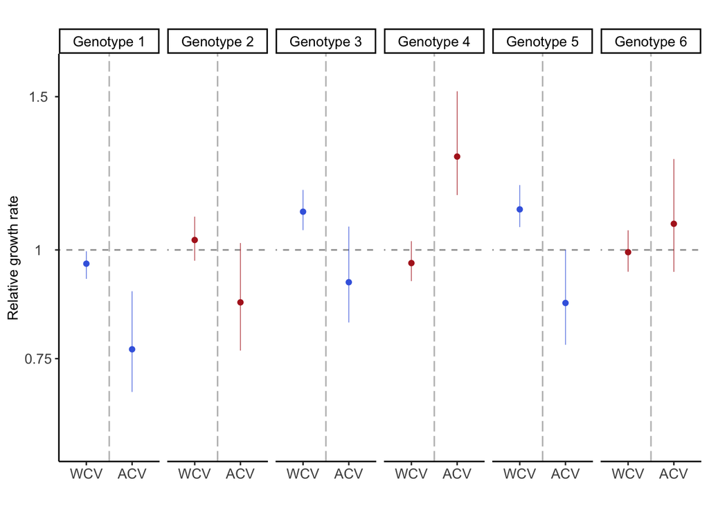

```r
## Overall fitness, per clade
Overall_fitness = ggplot(df_overall_fitness, aes(x = Time, y=Values, color = Genotype)) +
  geom_abline(slope = 0, intercept = log(1), linetype = "dashed", colour = 'grey60') +
  stat_summary(fun.data = f2, lwd = 0.2, alpha=1, position = position_dodge2(width = 0.2), geom = "pointrange")+
  theme_classic()+
  facet_grid(.~Genotype)+
  geom_vline(xintercept = 0, linetype = "longdash", color = 'grey')+
  scale_x_continuous(limits = c(-2,2),
                     breaks = c(-1,1),
                     labels = c('WCV', 'ACV'))+
  scale_y_continuous(trans = 'log', limits = c(0.6,1.6),
                     breaks = c(0.1, 0.25,0.5, 0.75, 1.0, 1.5, 2, 3, 10),
                     labels = c('<0.1', 0.25,0.5, 0.75, 1.0, 1.5, 2, 3, 10))+
  labs(title = "", x = '', y = 'Relative growth rate')+
  scale_color_manual(name = "Clades", values = c("royalblue", "firebrick","royalblue", "firebrick", "royalblue","firebrick"))+
  theme(plot.title = element_text (face = 'bold',size = 10,hjust = 0.5),
        legend.text = element_text(size = 10),
        legend.title = element_text(size = 10),
        axis.title.x = element_text(size=10),
        axis.title.y = element_text(size=10),
        axis.text.x = element_text(size = 10, hjust=0.5),
        axis.text.y = element_text(size = 10,hjust = 0.5),
        strip.text.x = element_text(size = 10, colour = "black", angle = 0),
        panel.grid.major = element_blank(),
        panel.grid.minor = element_blank(),
        legend.position = "none")

Overall_fitness
```

```r
################################################################################
```

#### Plot Figure 4B - effect vaccine switch

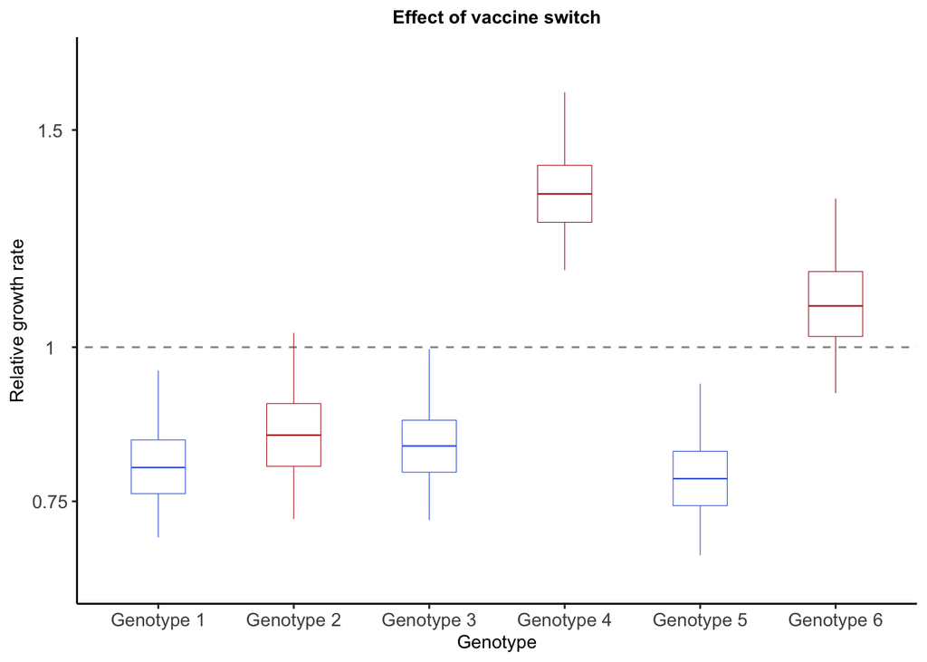

```r
## Plot effect vaccine switch
df_env_PRNdef = data.frame(x = c(seq(0,7,1), rev(seq(0,7,1))),
                    y = c(rep(mean.and.ci(df_effect_vaccine_shift_averages[which(df_effect_vaccine_shift_averages$Prn == 'prnneg'),]$Values)[2], length(seq(0,7,1))),
                          rep(mean.and.ci(df_effect_vaccine_shift_averages[which(df_effect_vaccine_shift_averages$Prn == 'prnneg'),]$Values)[3], length(seq(0,7,1)))))
df_env_PRNpos = data.frame(x = c(seq(0,7,1), rev(seq(0,7,1))),
                           y = c(rep(mean.and.ci(df_effect_vaccine_shift_averages[which(df_effect_vaccine_shift_averages$Prn == 'prnpos'),]$Values)[2], length(seq(0,7,1))),
                                 rep(mean.and.ci(df_effect_vaccine_shift_averages[which(df_effect_vaccine_shift_averages$Prn == 'prnpos'),]$Values)[3], length(seq(0,7,1)))))

Vaccine_switch_effect = ggplot(df_effect_vaccine_shift, aes(x = Genotype, y = Values)) +
  geom_abline(slope = 0, intercept = log(1), linetype = "dashed", colour = 'grey60') +
  stat_summary(fun.data = f, width = 0.4, alpha=0.5, lwd = 0.2, geom="boxplot", col = c("royalblue", "firebrick","royalblue", "firebrick", "royalblue","firebrick"))+
  theme_classic()+
  geom_vline(xintercept = 0, linetype = "longdash", color = 'grey')+
  scale_y_continuous(trans = 'log', limits = c(0.65,1.7),
                     breaks = c(0.1, 0.25,0.5, 0.75, 1.0, 1.5, 2,4,10),
                     labels = c('<0.1',0.25,0.5,0.75, 1, 1.5, 2,4,10))+
  labs(title = "Effect of vaccine switch", x = 'Genotype', y = 'Relative growth rate')+
  theme(plot.title = element_text (face = 'bold',size = 10,hjust = 0.5),
        legend.text = element_text(size = 10),
        legend.title = element_text(size = 10),
        axis.title.x = element_text(size=10),
        axis.title.y = element_text(size=10),
        axis.text.x = element_text(size = 10, hjust=0.5),
        axis.text.y = element_text(size = 10,hjust = 0.5),
        panel.grid.major = element_blank(),
        panel.grid.minor = element_blank(),
        legend.position = "none")

Vaccine_switch_effect
```

```r
################################################################################
```

#### Plot Figure 4C - effect of prn deficiency in whole-cell vaccine era

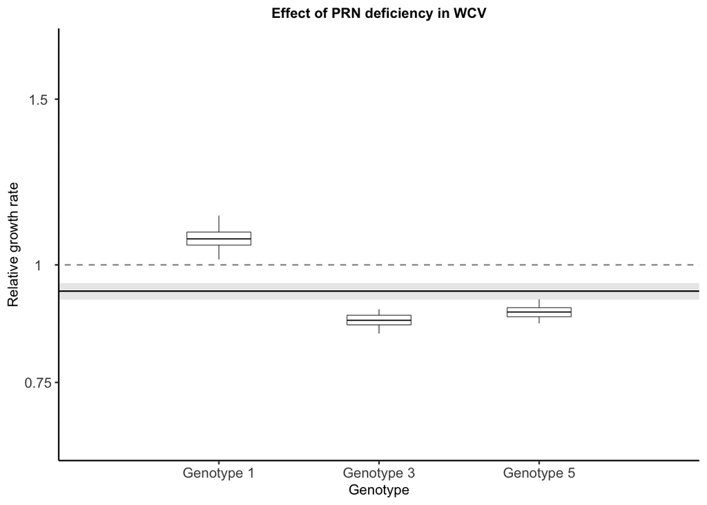

```r
## Effect prn, overall, by clade, WCV

df_env = data.frame(x = c(seq(0,4,1), rev(seq(0,4,1))),
                    y = c(rep(mean.and.ci(df_effect_prn_shift_averages[which(df_effect_prn_shift_averages$Time == -1),]$Values)[2], length(seq(0,4,1))),
                          rep(mean.and.ci(df_effect_prn_shift_averages[which(df_effect_prn_shift_averages$Time == -1),]$Values)[3], length(seq(0,4,1)))))

Effect_PRN_WCV = ggplot(df_effect_prn_shift[which(df_effect_prn_shift$Time == -1),], aes(x = Genotype, y = Values)) +
  geom_abline(slope = 0, intercept = log(1), linetype = "dashed", colour = 'grey60') +
  stat_summary(fun.data = f, width = 0.4, alpha=0.5, lwd = 0.2, geom="boxplot", col = 'Black')+
  theme_classic()+
  geom_vline(xintercept = 0, linetype = "longdash", color = 'grey')+
  scale_y_continuous(trans = 'log', limits = c(0.65,1.7),
                     breaks = c(0.1, 0.25,0.5, 0.75, 1.0, 1.5, 2,5,10),
                     labels = c('<0.1',0.25,0.5,0.75, 1, 1.5, 2,5,10))+
  labs(title = "Effect of PRN deficiency in WCV", x = 'Genotype', y = 'Relative growth rate')+
  theme(plot.title = element_text (face = 'bold',size = 10,hjust = 0.5),
        legend.text = element_text(size = 10),
        legend.title = element_text(size = 10),
        axis.title.x = element_text(size = 10),
        axis.title.y = element_text(size = 10),
        axis.text.x = element_text(size = 10, hjust=0.5),
        axis.text.y = element_text(size = 10,hjust = 0.5),
        panel.grid.major = element_blank(),
        panel.grid.minor = element_blank(),
        legend.position = "none")+
  geom_hline(yintercept = mean.and.ci(df_effect_prn_shift_averages[which(df_effect_prn_shift_averages$Time == -1),]$Values)[1]) +
  ggplot2::geom_polygon(data = df_env,
                        ggplot2::aes(x=x, y=y),
                        fill="black",  alpha=0.1)

Effect_PRN_WCV
```

#### Plot Figure 4C - effect of prn deficiency in acellular vaccine era

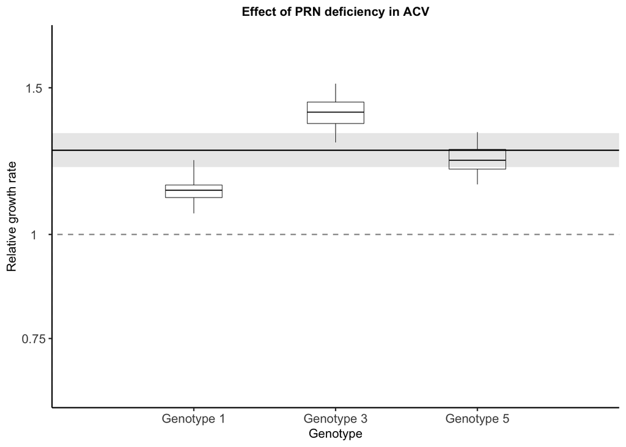

```r
## Effect prn, overall, by clade, ACV
df_env = data.frame(x = c(seq(0,4,1), rev(seq(0,4,1))),
                    y = c(rep(mean.and.ci(df_effect_prn_shift_averages[which(df_effect_prn_shift_averages$Time == 1),]$Values)[2], length(seq(0,4,1))),
                          rep(mean.and.ci(df_effect_prn_shift_averages[which(df_effect_prn_shift_averages$Time == 1),]$Values)[3], length(seq(0,4,1)))))

Effect_PRN_ACV = ggplot(df_effect_prn_shift[which(df_effect_prn_shift$Time == 1),], aes(x = Genotype, y = Values)) +
  geom_abline(slope = 0, intercept = log(1), linetype = "dashed", colour = 'grey60') +
  stat_summary(fun.data = f, width = 0.4, alpha=0.5, lwd = 0.2, geom="boxplot", col = 'Black')+
  theme_classic()+
  geom_vline(xintercept = 0, linetype = "longdash", color = 'grey')+
  scale_y_continuous(trans = 'log', limits = c(0.65,1.7),
                     breaks = c(0.1, 0.25,0.5, 0.75, 1.0, 1.5, 2,5,10),
                     labels = c('<0.1',0.25,0.5,0.75, 1, 1.5, 2,5,10))+
  labs(title = "Effect of PRN deficiency in ACV", x = 'Genotype', y = 'Relative growth rate')+
  theme(plot.title = element_text (face = 'bold',size = 10,hjust = 0.5),
        legend.text = element_text(size = 10),
        legend.title = element_text(size = 10),
        axis.title.x = element_text(size = 10),
        axis.title.y = element_text(size = 10),
        axis.text.x = element_text(size = 10, hjust=0.5),
        axis.text.y = element_text(size = 10,hjust = 0.5),
        panel.grid.major = element_blank(),
        panel.grid.minor = element_blank(),
        legend.position = "none") +
  geom_hline(yintercept = mean.and.ci(df_effect_prn_shift_averages[which(df_effect_prn_shift_averages$Time == 1),]$Values)[1]) +
  ggplot2::geom_polygon(data = df_env,
                        ggplot2::aes(x=x, y=y),
                        fill="black",  alpha=0.1)

Effect_PRN_ACV
```

## 3.2 - Compute model fits and plot them

```r
## Common parameters
nb_countries = Data$nb_countries # Number of countries
nb_genotypes = Data$nb_genotypes # Number genotypes
nb_years = Data$nb_years # Number years
ref_clade = 3 # Reference genotype
threshold = 5 ## Min number of isolates per year to plot
min_date = 1940
nb_chains = length(Chains$lp__)

# Country names, following the order in Data_MCMC
Cnty = c('AU', 'BE', 'CA', 'CN', 'CZ', 'DK', 'ES', 'FI', 'FR', 'IE', 'IL', 'IT', 'NL', 'NO', 'SE', 'UK', 'US', 'JP', 'IR', 'TN')

## Observed numbers per clade
numbers_obs_all_clades = array(NA, dim = c(nb_genotypes, nb_years, nb_countries))
for(i in 1:nb_countries){
  numbers_obs_all_clades[1:(nb_genotypes-1),,i] = Data$data_genotype_non_ref[,,i]
  numbers_obs_all_clades[nb_genotypes,,i] = Data$data_genotype_ref[,i]
}

## Colors to plot, per continent
colors_continents = c('saddlebrown', 'red3', 'orange2', 'darkgreen', 'royalblue2')
Continent_country_match = c(4, 5, 2, 3, 5, 5, 5, 5, 5, 5, 3, 5, 5, 5, 5, 5, 2, 3, 3, 1)
cols = colors_continents[Continent_country_match]

## Function for confidence intervals
mean.and.ci <-function(v){
  return( c(mean(v), as.numeric(quantile(v,probs = 0.025, na.rm = T)), as.numeric(quantile(v,probs = 0.975, na.rm = T))))
}
############################################################################################
```

### 3.2.A - Plot model fits for example countries

For each example country (Australia, France, USA, Japan), the following code: (1) computes the model fits (2) plots it

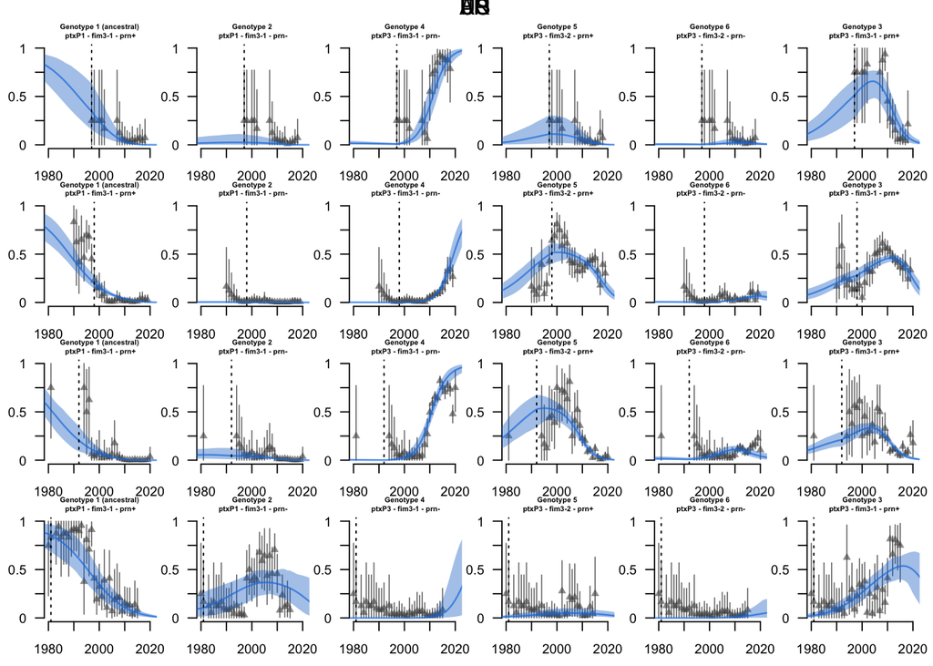

```r
## Sizes of labs, dots etc
cexlab = 0.9
cexaxis = 0.9
cexdots= 0.9
cexmain = 0.5

par(mfrow = c(4,6), oma = c(1,1,1,0), mai = c(0.2,0.2,0.2,0.1))

for(c in c(1,9,17,18)){ ## 1, 9, 17 and 18 are the indices of the example countries
  titles = c('Genotype 1 (ancestral) \n ptxP1 - fim3-1 - prn+ ',
             'Genotype 2 \nptxP1 - fim3-1 - prn-',
             'Genotype 4 \nptxP3 - fim3-1 - prn-',
             'Genotype 5 \nptxP3 - fim3-2 - prn+',
             'Genotype 6 \nptxP3 - fim3-2 - prn-',
             'Genotype 3 \n ptxP3 - fim3-1 - prn+') ## Names of the genotypes

  count = 1 ## count which gentoypes were already considered

  d = Data$data_genotype_non_ref[count,,c]

  for(i in 1:(nb_genotypes)){

    ## Part 1: compute the data points

    t = Data$data_total_number[,c]
    d_m = rep(0, length(d)) ## Vector to store the data mean
    d_ci = matrix(0, ncol = length(d), nrow = 2) ## Vector to store the data 95%ci, given binomial confidence intervals
    if(i < nb_genotypes){ ## if i is not the reference genotype
      d = Data$data_genotype_non_ref[count,,c]
      for(j in 1:nb_years){
        if(t[j]>0) {
          tmp = binom.confint(x = d[j], n = t[j], method = c("bayes"), type="central")
          d_m[j] = tmp$mean
          d_ci[1,j] = tmp$lower
          d_ci[2,j] = tmp$upper
        }
      }
      count = count +1
    }
    if(i == nb_genotypes){ ## if i = reference genotype
      d = Data$data_genotype_ref[,c]
      for(j in 1:nb_years){
        if(t[j]>0) {
          tmp = binom.confint(x = d[j], n = t[j], method = c("bayes"), type="central")
          d_m[j] = tmp$mean
          d_ci[1,j] = tmp$lower
          d_ci[2,j] = tmp$upper
        }
      }
    }
    zeros = Data$non_zero_country_year[,c] ## extract which year have no data

    d_m[which(zeros==0)] = NA ## Any year that was no data will not be plotted (NA)
    d_ci[1,which(zeros==0)] = NA ## Any year that was no data will not be plotted (NA)
    d_ci[2,which(zeros==0)] = NA ## Any year that was no data will not be plotted (NA)

    ## Part 2: extract model fit
    f = Chains$pred_absolute_freq[,c,i,1:nb_years]

    f[which(is.infinite(f)==T)] = NA
    f_mean_ci = apply(f, MARGIN = 2, function(x)mean.and.ci(x))


    ## Part 3: plot fit

    pch_times = Data$vaccine_introduction[c]

    if(pch_times>nb_years){pch_times=nb_years-1}
    if(pch_times<0){pch_times=1}
    if(i == 1 & c < 18)  {plot(1:nb_years, d_m, type="p", pch=c(rep(17, pch_times-1), rep(17, nb_years-pch_times+1)), bty = 'n',
                               xlab="", ylab = 'Proportion', ylim = c(0,1), xlim = c(40, nb_years-10),cex = cexdots,
                               main = titles[i], cex.main = cexmain,
                               col = adjustcolor('grey30', alpha.f = 0.6),
                               yaxt = 'n', xaxt = 'n', cex.lab = cexlab)}
    if(i == 1 & c == 18)  {plot(1:nb_years, d_m, type="p", pch=c(rep(17, pch_times-1), rep(17, nb_years-pch_times+1)), bty = 'n',
                                xlab="Time", ylab = 'Proportion', ylim = c(0,1),xlim = c(40, nb_years-10),cex = cexdots,
                                main = titles[i], cex.main = cexmain,
                                col = adjustcolor('grey30', alpha.f = 0.6),
                                yaxt = 'n', xaxt = 'n', cex.lab = cexlab)}
    if(i > 1 & c < 18)  {plot(1:nb_years, d_m, type="p", pch=c(rep(17, pch_times-1), rep(17, nb_years-pch_times+1)), bty = 'n',
                              xlab="", ylab = '', ylim = c(0,1),xlim = c(40, nb_years-10),cex = cexdots,
                              main = titles[i], cex.main = cexmain,
                              col = adjustcolor('grey30', alpha.f = 0.6),
                              yaxt = 'n', xaxt = 'n', cex.lab = cexlab)}
    if(i > 1 & c == 18)  {plot(1:nb_years, d_m, type="p", pch=c(rep(17, pch_times-1), rep(17, nb_years-pch_times+1)), bty = 'n',
                               xlab="Time (years)", ylab = '', ylim = c(0,1),xlim = c(40, nb_years-10), cex = cexdots,
                               main = titles[i], cex.main = cexmain,
                               col = adjustcolor('grey30', alpha.f = 0.6),
                               yaxt = 'n', xaxt = 'n', cex.lab = cexlab)}


    arrows(1:nb_years,d_ci[1,], 1:(nb_years),d_ci[2,], length=0, angle=0, code=3, lwd = 0.8,
           col = adjustcolor('grey30', alpha.f = 0.8))

    axis(2, las = 2, cex.axis = cexaxis, at = seq(0,1,0.25), labels = c("0", "", "0.5", "", "1"), lwd = 0.9)
    axis(1, at = seq(40, nb_years-10, 10), seq(40, nb_years-10, 10)+min_date, cex.axis = cexaxis, lwd = 0.9)

    lines(1:nb_years,f_mean_ci[1,], lwd = 1.25,
          cex=1.4,xlab="",ylab="",
          col = adjustcolor('dodgerblue2', alpha.f = 0.7))
    polygon(x = c(1:nb_years, rev(1:nb_years)),
            y = c(f_mean_ci[2,], rev(f_mean_ci[3,])), col = adjustcolor('dodgerblue3', alpha.f = 0.4), border = F)

    abline(v = Data$booster_introduction[c], lty = 3)
  }
  mtext(Cnty[c], outer = T, cex = 1)
}
```

### 3.2.B - Plot predicted *vs.* observed

Graphic parameters

```r
rd = c(2:17,19,20,18,1) ## order the country
cexdots= 0.8 ## size of dots
par(mfrow = c(1,1), mai = c(0.2,0.2,0.2,0.2))
```

#### Predicted *vs.* observed numbers

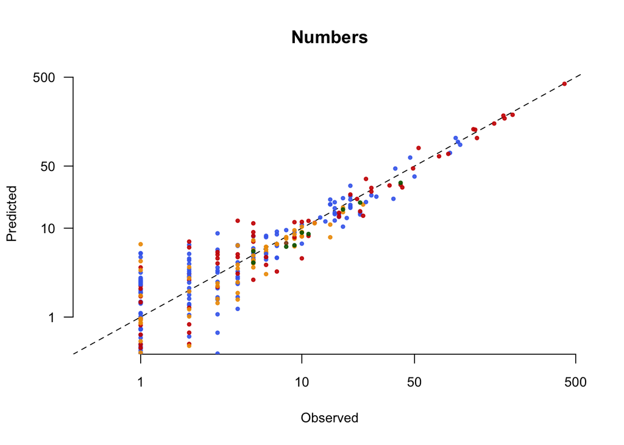

```r
numbers_obs = Data$data_genotype_non_ref
numbers_pred_m = numbers_pred_cimax = numbers_pred_cimin = array(0, dim = c(nb_genotypes-1, nb_years, nb_countries))
for(i in 1:nb_countries){
  for(j in 1:(nb_genotypes-1)){
    numbers_pred_m[j,,i] = apply(Chains$pred_number_non_ref[,i,j,], MARGIN = 2, function(x)mean.and.ci(x)[1])
    numbers_pred_cimin[j,,i] = apply(Chains$pred_number_non_ref[,i,j,], MARGIN = 2, function(x)mean.and.ci(x)[2])
    numbers_pred_cimax[j,,i] = apply(Chains$pred_number_non_ref[,i,j,], MARGIN = 2, function(x)mean.and.ci(x)[3])
  }
  numbers_obs[,which(colSums(numbers_obs_all_clades[,,i]) < threshold),i] = NA
}
plot(numbers_obs[,,rd[1]], numbers_pred_m[,,rd[1]], col = adjustcolor(cols[rd[1]], alpha.f = 0.9), pch = 20, xlab = 'Observed', ylab = 'Predicted', yaxt = 'n', bty = 'n', xaxt = 'n',
     main = "Numbers",
     cex.axis = cexaxis, cex.lab = cexlab, cex = cexdots,
     xlim = c(0.5,max(Chains$pred_number_non_ref)), ylim = c(0.5,max(Data$data_genotype_non_ref, na.rm=T)),
     log= 'xy')
abline(b=1, a=0, col = 'black', lty = 2)
axis(1, las = 1, cex.axis = cexaxis, at = c(1, 10, 50, 500), labels = c(1, 10, 50, 500))
axis(2, las = 2, cex.axis = cexaxis, at = c(1, 10, 50, 500), labels = c(1, 10, 50, 500))
for(i in 2:nb_countries){
  points(numbers_obs[,,rd[i]], numbers_pred_m[,,rd[i]], col = adjustcolor(cols[rd[i]], alpha.f = 0.9), pch = 20, cex = cexdots)
}
```

#### Predicted *vs.* observed frequencies

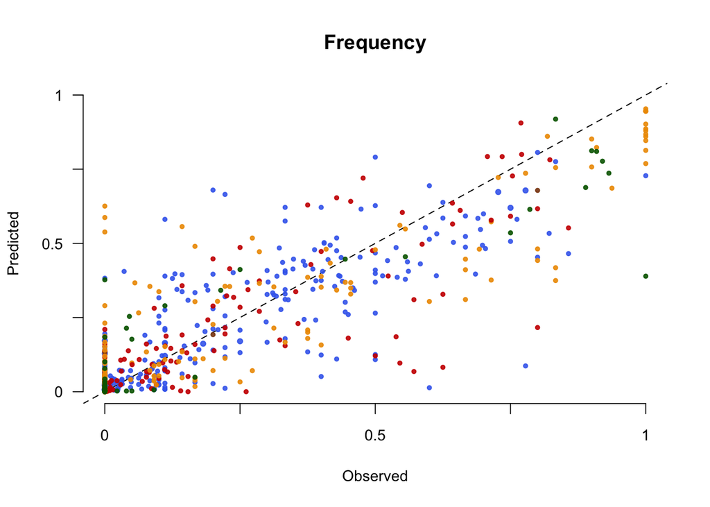

```r
freqs_obs = array(NA, dim = c(nb_genotypes, nb_years, nb_countries))
for(i in 1:nb_countries){
  for(j in 1:(nb_genotypes-1)){
    freqs_obs[j,,i] = Data$data_genotype_non_ref[j,,i]/Data$data_total_number[,i]
  }
  freqs_obs[nb_genotypes,,i] = Data$data_genotype_ref[,i]/Data$data_total_number[,i]

  freqs_obs[,which(colSums(numbers_obs_all_clades[,,i]) < threshold),i] = NA
}
freqs_obs[which(is.nan(freqs_obs))] = NA
freqs_pred_m = array(0, dim = c(nb_genotypes, nb_years, nb_countries))
freqs_pred_cimax = array(0, dim = c(nb_genotypes, nb_years, nb_countries))
freqs_pred_cimin = array(0, dim = c(nb_genotypes, nb_years, nb_countries))
for(i in 1:nb_countries){
  count = 1
  t = Data$data_total_number[,i]
  for(j in 1:(nb_genotypes-1)){
    tmp = t(apply(Chains$pred_number_non_ref[,i,count,], MARGIN = 1, function(x)x/t))
    freqs_pred_m[j,,i] = apply(tmp, MARGIN = 2, function(x)mean.and.ci(x)[1])
    freqs_pred_cimin[j,,i] = apply(tmp, MARGIN = 2, function(x)mean.and.ci(x)[2])
    freqs_pred_cimax[j,,i] = apply(tmp, MARGIN = 2, function(x)mean.and.ci(x)[3])
    count = count+1
  }
  f = t(apply(Chains$pred_number_ref[,i,], MARGIN = 1, function(x)x/t))
  freqs_pred_m[nb_genotypes,,i] = apply(f, MARGIN = 2, function(x)mean.and.ci(x)[1])
  freqs_pred_cimin[nb_genotypes,,i] = apply(f, MARGIN = 2, function(x)mean.and.ci(x)[2])
  freqs_pred_cimax[nb_genotypes,,i] = apply(f, MARGIN = 2, function(x)mean.and.ci(x)[3])
}
plot(freqs_obs[,,rd[1]], freqs_pred_m[,,rd[1]], col = adjustcolor(cols[rd[1]], alpha.f = 0.9),
     pch = 20, xlab = 'Observed', ylab = 'Predicted',
     yaxt = 'n', xaxt = 'n', bty='n',
     main = "Frequency",
     cex.axis = cexaxis, cex.lab = cexlab, xlim = c(0,1), ylim = c(0,1))
abline(b=1, a=0, col = 'black', lty = 2)
axis(2, las = 2, cex.axis = cexaxis, at = seq(0,1,0.25), labels = c("0", "", "0.5", "", "1"), lwd = 0.9)
axis(1, las = 1, cex.axis = cexaxis, at = seq(0,1,0.25), labels = c("0", "", "0.5", "", "1"), lwd = 0.9)
for(i in 2:nb_countries){
  points(freqs_obs[,,rd[i]], freqs_pred_m[,,rd[i]], col = adjustcolor(cols[rd[i]], alpha.f = 0.9), pch = 20, cex = cexdots)
}
```

#### Predicted *vs.* observed Wrightian fitness

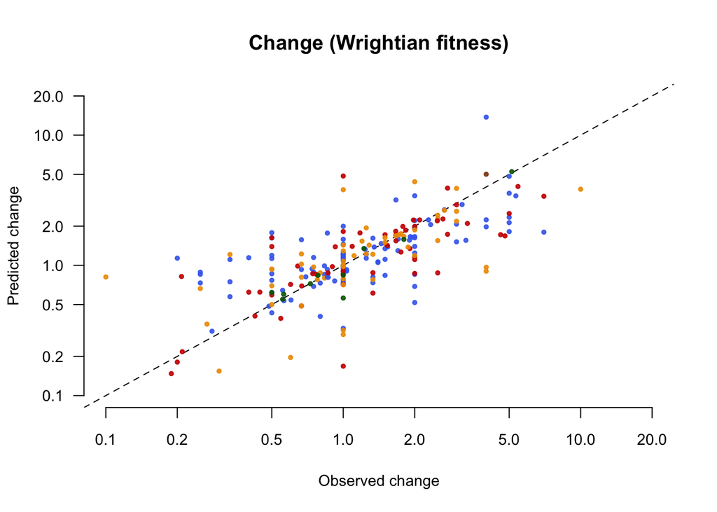

```r
change_obs = Data$data_genotype_non_ref[,-1,]/Data$data_genotype_non_ref[,-nb_years,]
change_obs[which(change_obs == 0)] = NA
change_pred_m = change_pred_cimin = change_pred_cimax =array(0, dim = c(nb_genotypes-1, nb_years-1, nb_countries))
for(i in 1:nb_countries){
  for(j in 1:(nb_genotypes-1)){
    for(t in 1:(nb_years-1)){
      change_pred_m[j,t,i] = mean.and.ci(Chains$pred_number_non_ref[,i,j,t+1]/Chains$pred_number_non_ref[,i,j,t])[1]
      change_pred_cimin[j,t,i] = mean.and.ci(Chains$pred_number_non_ref[,i,j,t+1]/Chains$pred_number_non_ref[,i,j,t])[2]
      change_pred_cimax[j,t,i] = mean.and.ci(Chains$pred_number_non_ref[,i,j,t+1]/Chains$pred_number_non_ref[,i,j,t])[3]
    }
  }
  change_obs[,which(colSums(numbers_obs_all_clades[,-1,i]) < threshold),i] = NA
}
plot(change_obs[,,rd[1]], change_pred_m[,,rd[1]], col = adjustcolor(cols[rd[1]], alpha.f = 0.9), pch = 20, xlab = 'Observed change', ylab = 'Predicted change', yaxt = 'n', bty = 'n',
     main = "Change (Wrightian fitness)",
     cex.axis = cexaxis, cex.lab = cexlab, xlim = c(0.1,20), ylim = c(0.1,20), cex = cexdots, log = 'xy')
abline(b=1, a=0, col = 'black', lty = 2, cex.axis = 1.2)
axis(2, las = 2, cex.axis = cexaxis)
for(i in 2:nb_countries){
  points(change_obs[,,rd[i]], change_pred_m[,,rd[i]], col = adjustcolor(cols[rd[i]], alpha.f = 0.9), pch = 20, cex = cexdots)

}
```

```r
################################################################################################################################
```